# 08_model_development_training_only

Yiwen Xiang

This file performs the Wave 11 machine-learning model-development analysis. All models use the same stratified 70/30 train-test split, but only the training set is used for feature screening, cross-validation, hyperparameter tuning, and final model fitting. Held-out test-set performance is evaluated separately in `09_heldout_test_evaluation.Rmd`.

# 1 1. Setup

```r
# Read in the cleaned Wave 11 modelling data and the saved candidate feature list from the previous script.
data11_training <- readRDS(
  file.path(processed_path, "07_wave11_ml_data.rds")
)

candidate_features <- readRDS(
  file.path(processed_path, "07_candidate_features.rds")
)

stopifnot(
  length(candidate_features) == 42L,
  !anyDuplicated(candidate_features),
  all(candidate_features %in% names(data11_training))
)

head(data11_training)
```

```
## # A tibble: 6 × 47
##   idauniq idahhw11 perid casp19_total qol_status    age sex    education_level
##     <dbl>    <dbl> <dbl>        <dbl> <fct>       <dbl> <fct>  <ord>
## 1  104178   102108     1           42 Non-low QoL    77 Male   Higher education
## 2  106612   102108     2           50 Non-low QoL    75 Female Higher education
## 3  104826   104365     1           34 Low QoL        90 Male   Middle education
## 4  105887   104365     2           35 Low QoL        90 Female Middle education
## 5  107226   101550     2           42 Non-low QoL    87 Female Middle education
## 6  108018   110961     1           38 Non-low QoL    82 Female <NA>
## # ℹ 39 more variables: marital_status <fct>, wealth_quintile <ord>,
## #   dhwork <fct>, housing_tenure <fct>, financial_difficulty <ord>,
## #   self_rated_health <ord>, long_standing_illness <ord>, chronic_pain <ord>,
## #   eyesight_problem <ord>, hearing_problem <ord>, arthritis <fct>,
## #   diabetes <fct>, cvd <fct>, cancer <fct>, chronic_lung_disease <fct>,
## #   asthma <fct>, adl_count <int>, iadl_count <int>, mobility_count <int>,
## #   cesd_score <dbl>, restless_sleep <fct>, loneliness_score <dbl>, …
```

```r
# Print the candidate feature names once, so the modelling input list is easy to check.
candidate_features
```

```
##  [1] "age"                               "sex"
##  [3] "education_level"                   "marital_status"
##  [5] "wealth_quintile"                   "dhwork"
##  [7] "housing_tenure"                    "financial_difficulty"
##  [9] "self_rated_health"                 "long_standing_illness"
## [11] "chronic_pain"                      "eyesight_problem"
## [13] "hearing_problem"                   "arthritis"
## [15] "diabetes"                          "cvd"
## [17] "cancer"                            "chronic_lung_disease"
## [19] "asthma"                            "adl_count"
## [21] "iadl_count"                        "mobility_count"
## [23] "cesd_score"                        "restless_sleep"
## [25] "loneliness_score"                  "social_participation_count"
## [27] "internet_help_frequency"           "social_relationship_quality_score"
## [29] "caring_responsibilities"           "smoking_status"
## [31] "alcohol_frequency_group"           "physical_activity_level"
## [33] "orientation_score"                 "food_insecurity"
## [35] "subjective_social_status"          "anxiety_score"
## [37] "objective_memory_score"            "self_rated_memory"
## [39] "memory_change"                     "any_psychiatric_problem"
## [41] "any_received_care_help"            "chronic_disease_count"
```

```r
# Check the imported sample size and column count before creating analysis subsets.
dim(data11_training)
```

```
## [1] 5313   47
```

```r
# Create one stratified train-test split and save its IDs before any model development.
set.seed(123)

data11_split <- initial_split(
  data11_training,
  prop = 0.7,
  strata = qol_status
)

data11_train <- training(data11_split)
data11_test <- testing(data11_split)

split_ids <- list(
  train_idauniq = data11_train$idauniq,
  test_idauniq = data11_test$idauniq
)

saveRDS(
  split_ids,
  file.path(processed_path, "08_train_test_split_ids.rds")
)

stopifnot(
  length(
    intersect(
      split_ids$train_idauniq,
      split_ids$test_idauniq
    )
  ) == 0
)
```

# 2 2. ID variables, outcome variables, continuous variables, and categorical variables

```r
# Keep identifiers and outcomes separate from predictors before building the feature groups.
id_vars <- c("idauniq", "idahhw11", "perid")
outcome_vars <- c("casp19_total", "qol_status")
```

```r
# Pull out the numeric candidate predictors for the continuous-variable checks and preprocessing.
continuous_vars <- data11_training %>%
  select(all_of(candidate_features)) %>%
  select(where(is.numeric)) %>%
  names()

continuous_vars
```

```
##  [1] "age"                               "adl_count"
##  [3] "iadl_count"                        "mobility_count"
##  [5] "cesd_score"                        "loneliness_score"
##  [7] "social_participation_count"        "social_relationship_quality_score"
##  [9] "orientation_score"                 "subjective_social_status"
## [11] "anxiety_score"                     "objective_memory_score"
## [13] "self_rated_memory"                 "memory_change"
## [15] "chronic_disease_count"
```

```r
# Pull out the factor candidate predictors so categorical variables can be handled separately.
categorical_vars <- data11_training %>%
  select(all_of(candidate_features)) %>%
  select(where(is.factor)) %>%
  names()

categorical_vars
```

```
##  [1] "sex"                     "education_level"
##  [3] "marital_status"          "wealth_quintile"
##  [5] "dhwork"                  "housing_tenure"
##  [7] "financial_difficulty"    "self_rated_health"
##  [9] "long_standing_illness"   "chronic_pain"
## [11] "eyesight_problem"        "hearing_problem"
## [13] "arthritis"               "diabetes"
## [15] "cvd"                     "cancer"
## [17] "chronic_lung_disease"    "asthma"
## [19] "restless_sleep"          "internet_help_frequency"
## [21] "caring_responsibilities" "smoking_status"
## [23] "alcohol_frequency_group" "physical_activity_level"
## [25] "food_insecurity"         "any_psychiatric_problem"
## [27] "any_received_care_help"
```

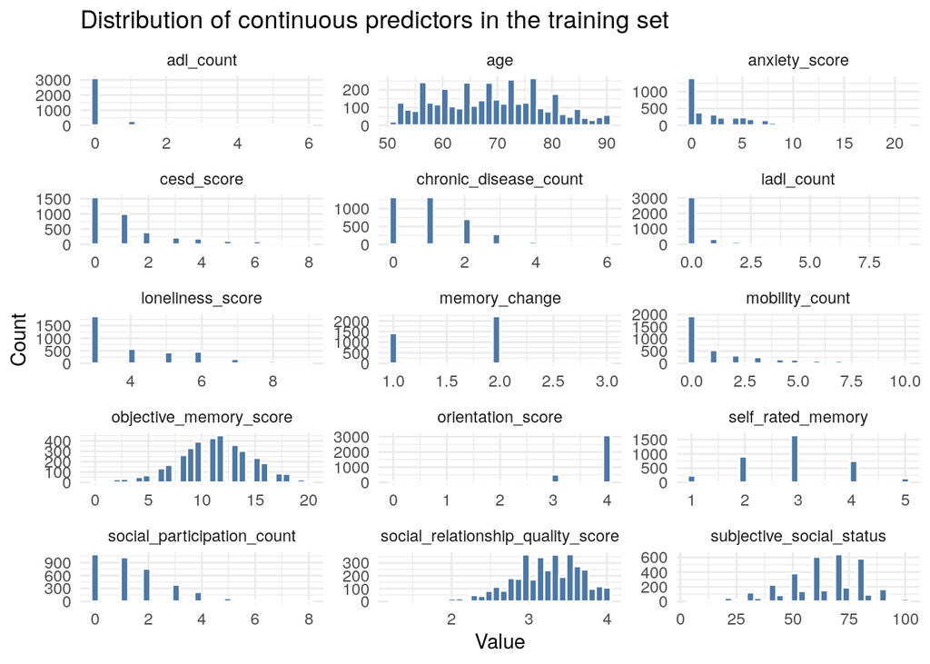

```r
# Reshape the continuous predictors in the training set and scan their distributions before choosing imputation rules.
continuous_long <- data11_train %>%
  select(all_of(continuous_vars)) %>%
  pivot_longer(
    cols = everything(),
    names_to = "variable",
    values_to = "value"
  )

ggplot(continuous_long, aes(x = value)) +
  geom_histogram(bins = 30, fill = "#4C78A8", color = "white", na.rm = TRUE) +
  facet_wrap(~ variable, scales = "free", ncol = 3) +
  theme_minimal() +
  labs(
    title = "Distribution of continuous predictors in the training set",
    x = "Value",
    y = "Count"
  )
```

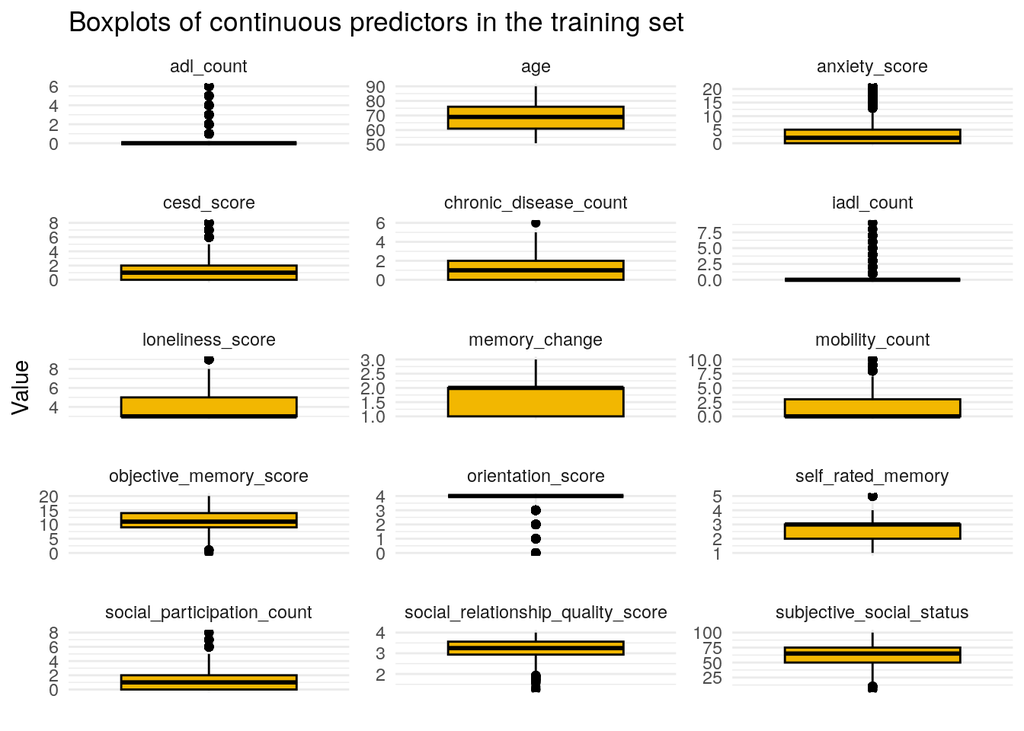

```r
# Use boxplots as a second quick check for skewness and extreme values in the continuous predictors.
ggplot(continuous_long, aes(x = "", y = value)) +
  geom_boxplot(fill = "#F2B701", color = "black", na.rm = TRUE) +
  facet_wrap(~ variable, scales = "free", ncol = 3) +
  theme_minimal() +
  labs(
    title = "Boxplots of continuous predictors in the training set",
    x = NULL,
    y = "Value"
  )
```

```r
# Summarise missingness and spread for each continuous predictor in one table.
continuous_summary <- map_dfr(
  continuous_vars,
  function(v) {
    x <- data11_train[[v]]

    tibble(
      variable = v,
      n_non_missing = sum(!is.na(x)),
      n_missing = sum(is.na(x)),
      missing_percent = round(mean(is.na(x)) * 100, 2),
      mean = round(mean(x, na.rm = TRUE), 2),
      median = round(median(x, na.rm = TRUE), 2),
      mean_minus_median = round(mean(x, na.rm = TRUE) - median(x, na.rm = TRUE), 2),
      sd = round(sd(x, na.rm = TRUE), 2),
      min = min(x, na.rm = TRUE),
      q1 = quantile(x, 0.25, na.rm = TRUE),
      q3 = quantile(x, 0.75, na.rm = TRUE),
      max = max(x, na.rm = TRUE)
    )
  }
)

continuous_summary
```

```
## # A tibble: 15 × 12
##    variable                 n_non_missing n_missing missing_percent  mean median
##    <chr>                            <int>     <int>           <dbl> <dbl>  <dbl>
##  1 age                               3718         0            0    68.8   69
##  2 adl_count                         3718         0            0     0.34   0
##  3 iadl_count                        3718         0            0     0.38   0
##  4 mobility_count                    3718         0            0     1.66   0
##  5 cesd_score                        3680        38            1.02  1.41   1
##  6 loneliness_score                  3685        33            0.89  4.19   3
##  7 social_participation_co…          3583       135            3.63  1.44   1
##  8 social_relationship_qua…          3710         8            0.22  3.22   3.25
##  9 orientation_score                 3718         0            0     3.78   4
## 10 subjective_social_status          3581       137            3.68 63.3   65
## 11 anxiety_score                     3595       123            3.31  3.34   2
## 12 objective_memory_score            3651        67            1.8  11.2   11
## 13 self_rated_memory                 3700        18            0.48  2.91   3
## 14 memory_change                     3698        20            0.54  1.63   2
## 15 chronic_disease_count             3718         0            0     1.06   1
## # ℹ 6 more variables: mean_minus_median <dbl>, sd <dbl>, min <dbl>, q1 <dbl>,
## #   q3 <dbl>, max <dbl>
```

Considering that most numerical predictive variables exhibit skewed distributions or are discrete count variables, the median of the training set is less susceptible to extreme values than the mean. Therefore, it is used to fill in the missing values of numerical variables. For categorical variables, missing values are encoded as a separate “Missing” category to retain the information that the missing pattern may contain, while avoiding the introduction of additional uncertainty from random filling.

# 3 3. Train/test split checks

```r
# Check that the train and test sets have the expected sizes after splitting.
dim(data11_train)
```

```
## [1] 3718   47
```

```r
dim(data11_test)
```

```
## [1] 1595   47
```

```r
# Compare outcome balance in the train and test sets after stratification.
data11_train %>%
  count(qol_status) %>%
  mutate(percent = round(n / sum(n) * 100, 2))
```

```
## # A tibble: 2 × 3
##   qol_status      n percent
##   <fct>       <int>   <dbl>
## 1 Non-low QoL  2778    74.7
## 2 Low QoL       940    25.3
```

```r
data11_test %>%
  count(qol_status) %>%
  mutate(percent = round(n / sum(n) * 100, 2))
```

```
## # A tibble: 2 × 3
##   qol_status      n percent
##   <fct>       <int>   <dbl>
## 1 Non-low QoL  1191    74.7
## 2 Low QoL       404    25.3
```

```r
# Check whether the training-set CASP-19 first quartile is consistent with
# the current Low QoL cut-off.
# The main analysis defines Low QoL as CASP-19 <= 35.

qol_cutoff_main <- 35

casp19_q1_check <- tibble(
  sample = "Training set",
  n_non_missing_casp19 = sum(!is.na(data11_train$casp19_total)),
  casp19_q1 = as.numeric(
    quantile(data11_train$casp19_total, probs = 0.25, na.rm = TRUE)
  )
) %>%
  mutate(
    main_cutoff = qol_cutoff_main,
    same_as_main_cutoff = abs(casp19_q1 - main_cutoff) < 1e-8
  )

casp19_q1_check
```

```
## # A tibble: 1 × 5
##   sample       n_non_missing_casp19 casp19_q1 main_cutoff same_as_main_cutoff
##   <chr>                       <int>     <dbl>       <dbl> <lgl>
## 1 Training set                 3718        35          35 TRUE
```

```r
# Format the outcome counts for Table 1 across the full sample, training set, and test set.
# Result: Table 1. Outcome distribution in analytical sample, training set and held-out test set

make_outcome_distribution <- function(data, dataset_label) {
  data %>%
    count(qol_status, name = "n") %>%
    mutate(
      Dataset = dataset_label,
      N = sum(n),
      percent = round(n / N * 100, 1),
      display = paste0(n, " (", percent, "%)")
    ) %>%
    select(Dataset, N, qol_status, display) %>%
    pivot_wider(
      names_from = qol_status,
      values_from = display
    )
}

table1_outcome_distribution <- bind_rows(
  make_outcome_distribution(data11_training, "Full analytical sample"),
  make_outcome_distribution(data11_train, "Training set"),
  make_outcome_distribution(data11_test, "Held-out test set")
) %>%
  select(
    Dataset,
    N,
    `Low QoL`,
    `Non-low QoL`
  ) %>%
  rename(
    `Low QoL n (%)` = `Low QoL`,
    `Non-low QoL n (%)` = `Non-low QoL`
  )

table1_outcome_distribution
```

```
## # A tibble: 3 × 4
##   Dataset                    N `Low QoL n (%)` `Non-low QoL n (%)`
##   <chr>                  <int> <chr>           <chr>
## 1 Full analytical sample  5313 1344 (25.3%)    3969 (74.7%)
## 2 Training set            3718 940 (25.3%)     2778 (74.7%)
## 3 Held-out test set       1595 404 (25.3%)     1191 (74.7%)
```

```r
# Save the outcome distribution table
write_xlsx(
  table1_outcome_distribution,
  file.path(output_path, "08_outcome_distribution.xlsx")
)
```

```r
# Save raw numeric values for the sample characteristics table.
numeric_summary <- function(data, variable, dataset_label, stats = c("mean", "sd")) {
  x <- data[[variable]]

  values <- c(
    n = sum(!is.na(x)),
    mean = mean(x, na.rm = TRUE),
    sd = sd(x, na.rm = TRUE),
    median = median(x, na.rm = TRUE),
    q1 = quantile(x, 0.25, na.rm = TRUE, names = FALSE),
    q3 = quantile(x, 0.75, na.rm = TRUE, names = FALSE)
  )

  tibble(
    dataset = dataset_label,
    variable = variable,
    statistic = stats,
    value = round(as.numeric(values[stats]), 2)
  )
}

category_summary <- function(data, variable, levels, output_name, dataset_label) {
  x <- as.character(data[[variable]])
  denominator <- sum(!is.na(x))
  n <- sum(x %in% levels, na.rm = TRUE)

  tibble(
    dataset = dataset_label,
    variable = output_name,
    statistic = c("n", "percent", "denominator"),
    value = c(n, round(n / denominator * 100, 1), denominator)
  )
}

make_sample_characteristics_raw <- function(data, dataset_label) {
  bind_rows(
    tibble(
      dataset = dataset_label,
      variable = "sample",
      statistic = "n",
      value = nrow(data)
    ),
    numeric_summary(data, "age", dataset_label, c("n", "mean", "sd")),
    category_summary(data, "sex", "Female", "female", dataset_label),
    category_summary(
      data,
      "financial_difficulty",
      c("Moderate financial difficulty", "High financial difficulty"),
      "moderate_high_financial_difficulty",
      dataset_label
    ),
    category_summary(data, "self_rated_health", c("Fair", "Poor"), "fair_poor_self_rated_health", dataset_label),
    category_summary(data, "long_standing_illness", "Limiting long-standing illness", "limiting_long_standing_illness", dataset_label),
    numeric_summary(data, "mobility_count", dataset_label, c("n", "median", "q1", "q3")),
    numeric_summary(data, "cesd_score", dataset_label, c("n", "median", "q1", "q3")),
    numeric_summary(data, "anxiety_score", dataset_label, c("n", "median", "q1", "q3")),
    numeric_summary(data, "loneliness_score", dataset_label, c("n", "median", "q1", "q3")),
    numeric_summary(data, "social_relationship_quality_score", dataset_label, c("n", "mean", "sd")),
    category_summary(data, "qol_status", c("Low QoL", "Low_QoL"), "low_qol", dataset_label)
  )
}

sample_characteristics_raw <- bind_rows(
  make_sample_characteristics_raw(data11_training, "Analytic sample"),
  make_sample_characteristics_raw(data11_train, "Training set"),
  make_sample_characteristics_raw(data11_test, "Held-out test set")
)

sample_characteristics_raw
```

```
## # A tibble: 114 × 4
##    dataset         variable                           statistic     value
##    <chr>           <chr>                              <chr>         <dbl>
##  1 Analytic sample sample                             n           5313
##  2 Analytic sample age                                n           5313
##  3 Analytic sample age                                mean          68.7
##  4 Analytic sample age                                sd             9.67
##  5 Analytic sample female                             n           3035
##  6 Analytic sample female                             percent       57.1
##  7 Analytic sample female                             denominator 5313
##  8 Analytic sample moderate_high_financial_difficulty n           1147
##  9 Analytic sample moderate_high_financial_difficulty percent       23.1
## 10 Analytic sample moderate_high_financial_difficulty denominator 4956
## # ℹ 104 more rows
```

```r
# Save raw values for manual table formatting in Excel.
write_xlsx(
  list(
    sample_characteristics_raw = sample_characteristics_raw
  ),
  file.path(output_path, "08_sample_characteristics_train_test.xlsx")
)
```

## 3.1 3.1 Common classification metrics and helper settings

```r
# Use one shared metric set so all classification models are evaluated in the same way.
# Low_QoL is the positive event for all classification metrics.
options(yardstick.event_first = TRUE)

classification_metrics <- metric_set(
  roc_auc,
  pr_auc,
  accuracy,
  precision,
  sens,
  spec,
  f_meas
)
```

# 4 4. LASSO logistic regression

```r
# Prepare the classification outcome and explicitly restrict predictors to the 42 candidate features.
set.seed(123)


data11_train_cls <- data11_train %>%
  select(
    qol_status,
    all_of(candidate_features)
  ) %>%
  mutate(
    qol_status = case_when(
      as.character(qol_status) %in% c("Low QoL", "Low_QoL") ~ "Low_QoL",
      as.character(qol_status) %in% c("Non-low QoL", "Non_low_QoL") ~ "Non_low_QoL",
      TRUE ~ as.character(qol_status)
    ),
    qol_status = factor(qol_status, levels = c("Low_QoL", "Non_low_QoL")),
    across(where(is.ordered), ~ factor(.x, ordered = FALSE))
  )
```

```r
# Define the LASSO preprocessing recipe: impute, encode categories, drop zero-variance terms, then standardise.
lasso_recipe <- recipe(qol_status ~ ., data = data11_train_cls) %>%
  step_impute_median(all_numeric_predictors()) %>%

  step_unknown(all_nominal_predictors(), new_level = "Missing") %>%

  step_novel(all_nominal_predictors(), new_level = "New") %>%

  step_dummy(all_nominal_predictors()) %>%

  step_zv(all_predictors()) %>%

  step_normalize(all_numeric_predictors())
```

```r
# Set up logistic LASSO with the penalty left for cross-validation to choose.
lasso_model <- logistic_reg(
  mode = "classification",
  penalty = tune(),
  mixture = 1
) %>%
  set_engine("glmnet")
```

```r
# Combine the preprocessing recipe and logistic LASSO model into one workflow.
lasso_workflow <- workflow() %>%
  add_recipe(lasso_recipe) %>%
  add_model(lasso_model)
```

```r
# Create stratified folds so the low-QoL class is represented in each resample.
set.seed(123)

cv_folds <- vfold_cv(
  data11_train_cls,
  v = 10,
  strata = qol_status
)
```

```r
# Set the lambda search range from weak to stronger penalisation.
lambda_grid <- grid_regular(
  penalty(range = c(-5, 0)),
  levels = 50
)
```

```r
# Run cross-validation to find the lambda that gives the best held-out performance within training data.
set.seed(123)

lasso_tune <- tune_grid(
  lasso_workflow,
  resamples = cv_folds,
  grid = lambda_grid,
  metrics = classification_metrics
)
```

[output not shown]

[output not shown]

```r
# Inspect the tuning results before selecting the final lambda.
lasso_metrics <- collect_metrics(lasso_tune)

lasso_metrics
```

```
## # A tibble: 350 × 7
##      penalty .metric   .estimator  mean     n std_err .config
##        <dbl> <chr>     <chr>      <dbl> <int>   <dbl> <chr>
##  1 0.00001   accuracy  binary     0.859    10 0.00377 Preprocessor1_Model01
##  2 0.00001   f_meas    binary     0.689    10 0.0113  Preprocessor1_Model01
##  3 0.00001   pr_auc    binary     0.807    10 0.00770 Preprocessor1_Model01
##  4 0.00001   precision binary     0.779    10 0.0121  Preprocessor1_Model01
##  5 0.00001   roc_auc   binary     0.912    10 0.00360 Preprocessor1_Model01
##  6 0.00001   sens      binary     0.622    10 0.0206  Preprocessor1_Model01
##  7 0.00001   spec      binary     0.939    10 0.00619 Preprocessor1_Model01
##  8 0.0000126 accuracy  binary     0.859    10 0.00377 Preprocessor1_Model02
##  9 0.0000126 f_meas    binary     0.689    10 0.0113  Preprocessor1_Model02
## 10 0.0000126 pr_auc    binary     0.807    10 0.00770 Preprocessor1_Model02
## # ℹ 340 more rows
```

```r
# Choose the LASSO penalty by ROC AUC, keeping the feature selection tied to classification performance.
best_lambda <- select_best(
  lasso_tune,
  metric = "roc_auc"
)

best_lambda
```

```
## # A tibble: 1 × 2
##   penalty .config
##     <dbl> <chr>
## 1 0.00450 Preprocessor1_Model27
```

```r
# Refit the final logistic LASSO model on the full training set using the selected lambda.
final_lasso_workflow <- finalize_workflow(
  lasso_workflow,
  best_lambda
)

final_lasso_fit <- fit(
  final_lasso_workflow,
  data = data11_train_cls
)
```

```r
# Extract the non-zero LASSO coefficients, which are the model terms retained after penalisation.
lasso_selected_vars <- final_lasso_fit %>%
  extract_fit_parsnip() %>%
  tidy() %>%
  filter(term != "(Intercept)") %>%
  filter(estimate != 0) %>%
  arrange(desc(abs(estimate)))

lasso_selected_vars
```

```
## # A tibble: 45 × 3
##    term                              estimate penalty
##    <chr>                                <dbl>   <dbl>
##  1 loneliness_score                    -0.634 0.00450
##  2 anxiety_score                       -0.594 0.00450
##  3 cesd_score                          -0.491 0.00450
##  4 social_relationship_quality_score    0.431 0.00450
##  5 subjective_social_status             0.349 0.00450
##  6 self_rated_health_Poor              -0.225 0.00450
##  7 self_rated_health_Good              -0.211 0.00450
##  8 sex_Female                           0.194 0.00450
##  9 self_rated_health_Fair              -0.186 0.00450
## 10 food_insecurity_Yes                 -0.184 0.00450
## # ℹ 35 more rows
```

The coefficient importance plot below aggregates retained logistic LASSO coefficients to the original-variable level. This keeps the interpretation focused on the top original predictors, rather than on individual dummy levels. The plot describes model-based predictive importance, not causal effects.

```r
# Aggregate non-zero logistic LASSO coefficients to original-variable importance.
lasso_original_predictors <- setdiff(
  names(data11_train_cls),
  "qol_status"
)

lasso_variable_importance <- lasso_selected_vars %>%
  mutate(
    original_feature = map_chr(
      term,
      function(term_i) {
        if (term_i %in% lasso_original_predictors) {
          return(term_i)
        }

        candidates <- lasso_original_predictors[
          map_lgl(
            lasso_original_predictors,
            ~ str_starts(term_i, paste0(.x, "_"))
          )
        ]

        if (length(candidates) == 0) {
          return(term_i)
        }

        candidates[which.max(nchar(candidates))]
      }
    ),
    abs_estimate = abs(estimate)
  ) %>%
  group_by(original_feature) %>%
  summarise(
    coefficient_importance = sqrt(sum(estimate^2)),
    n_terms = n(),
    dominant_term = term[which.max(abs_estimate)],
    dominant_estimate = estimate[which.max(abs_estimate)],
    terms = paste(term, collapse = "; "),
    .groups = "drop"
  ) %>%
  arrange(desc(coefficient_importance)) %>%
  mutate(rank = row_number())

lasso_variable_importance
```

```
## # A tibble: 30 × 7
##    original_feature                 coefficient_importance n_terms dominant_term
##    <chr>                                             <dbl>   <int> <chr>
##  1 loneliness_score                                  0.634       1 loneliness_s…
##  2 anxiety_score                                     0.594       1 anxiety_score
##  3 cesd_score                                        0.491       1 cesd_score
##  4 social_relationship_quality_sco…                  0.431       1 social_relat…
##  5 self_rated_health                                 0.367       4 self_rated_h…
##  6 subjective_social_status                          0.349       1 subjective_s…
##  7 sex                                               0.194       1 sex_Female
##  8 physical_activity_level                           0.191       3 physical_act…
##  9 food_insecurity                                   0.184       1 food_insecur…
## 10 social_participation_count                        0.141       1 social_parti…
## # ℹ 20 more rows
## # ℹ 3 more variables: dominant_estimate <dbl>, terms <chr>, rank <int>
```

```r
# Export the full logistic LASSO feature-importance results for audit and reporting.
write_xlsx(
  list(
    original_feature_importance = lasso_variable_importance,
    nonzero_model_terms = lasso_selected_vars
  ),
  file.path(output_path, "08_lasso_logistic_feature_importance.xlsx")
)
```

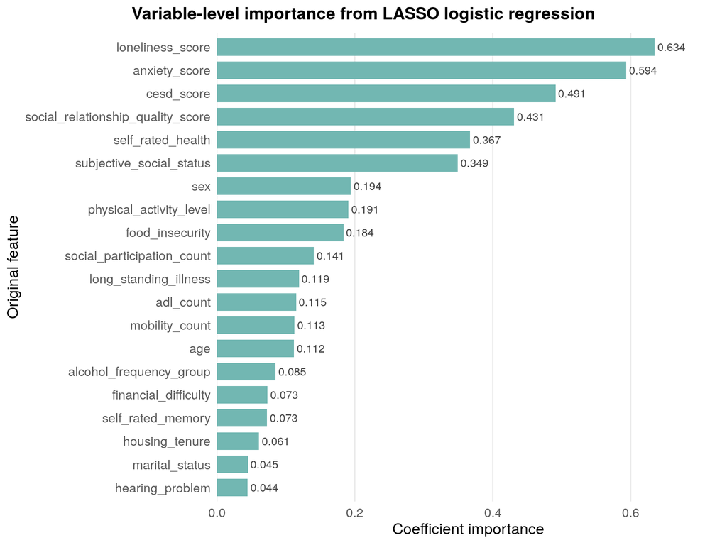

```r
# Plot the top 20 original features by logistic LASSO coefficient importance.
lasso_variable_importance_top20 <- lasso_variable_importance %>%
  slice_head(n = 20) %>%
  mutate(
    original_feature = factor(original_feature, levels = rev(original_feature)),
    importance_label = sprintf("%.3f", coefficient_importance)
  )

lasso_logistic_importance_plot <- ggplot(
  lasso_variable_importance_top20,
  aes(
    x = original_feature,
    y = coefficient_importance
  )
) +
  geom_col(fill = "#72B7B2", width = 0.75) +
  geom_text(
    aes(label = importance_label),
    hjust = -0.1,
    size = 3.1,
    color = "grey25"
  ) +
  scale_y_continuous(expand = expansion(mult = c(0, 0.15))) +
  coord_flip() +
  theme_minimal(base_size = 11) +
  theme(
    plot.title = element_text(
      hjust = 0.5,
      face = "bold",
      margin = margin(b = 8)
    ),
    plot.title.position = "plot",
    axis.title = element_text(size = 12, face = "plain", color = "black"),
    axis.text = element_text(size = 10, color = "grey35"),
    panel.grid.major.y = element_blank(),
    panel.grid.minor = element_blank(),
    legend.position = "none"
  ) +
  labs(
    title = "Variable-level importance from LASSO logistic regression",
    x = "Original feature",
    y = "Coefficient importance"
  )

lasso_logistic_importance_plot
```

```r
# Export the logistic LASSO variable-level importance plot.
ggsave(
  filename = file.path(
    picture_path,
    "08_lasso_logistic_variable_importance_top20.png"
  ),
  plot = lasso_logistic_importance_plot,
  width = 8,
  height = 6,
  dpi = 300
)
```

# 5 5. LASSO linear regression

```r
# Prepare the continuous-outcome dataset using the 42 candidate predictors.
set.seed(123)

data11_train_lm <- data11_train %>%
  select(
    casp19_total,
    all_of(candidate_features)
  ) %>%
  mutate(
    across(where(is.ordered), ~ factor(.x, ordered = FALSE))
  )
```

```r
# Use the same preprocessing logic for the linear LASSO model, now predicting CASP-19 total score.
lasso_lm_recipe <- recipe(casp19_total ~ ., data = data11_train_lm) %>%
  step_impute_median(all_numeric_predictors()) %>%
  step_unknown(all_nominal_predictors(), new_level = "Missing") %>%
  step_novel(all_nominal_predictors(), new_level = "New") %>%
  step_dummy(all_nominal_predictors()) %>%
  step_zv(all_predictors()) %>%
  step_normalize(all_numeric_predictors())
```

```r
# Set up linear LASSO and tune the penalty through cross-validation.
lasso_lm_model <- linear_reg(
  mode = "regression",
  penalty = tune(),
  mixture = 1
) %>%
  set_engine("glmnet")

lasso_lm_workflow <- workflow() %>%
  add_recipe(lasso_lm_recipe) %>%
  add_model(lasso_lm_model)
```

```r
# Create folds and the lambda grid for the continuous-outcome LASSO model.
set.seed(123)

cv_folds_lm <- vfold_cv(
  data11_train_lm,
  v = 10
)

lambda_grid_lm <- grid_regular(
  penalty(range = c(-5, 0)),
  levels = 50
)
```

```r
# Tune the linear LASSO using regression metrics on the training folds.
set.seed(123)

lasso_lm_tune <- tune_grid(
  lasso_lm_workflow,
  resamples = cv_folds_lm,
  grid = lambda_grid_lm,
  metrics = metric_set(rmse, rsq, mae)
)
```

```r
# Review the regression tuning results and choose the lambda with the lowest RMSE.
lasso_lm_metrics <- collect_metrics(lasso_lm_tune)

lasso_lm_metrics
```

```
## # A tibble: 150 × 7
##      penalty .metric .estimator  mean     n std_err .config
##        <dbl> <chr>   <chr>      <dbl> <int>   <dbl> <chr>
##  1 0.00001   mae     standard   4.28     10 0.0422  Preprocessor1_Model01
##  2 0.00001   rmse    standard   5.52     10 0.0706  Preprocessor1_Model01
##  3 0.00001   rsq     standard   0.659    10 0.00804 Preprocessor1_Model01
##  4 0.0000126 mae     standard   4.28     10 0.0422  Preprocessor1_Model02
##  5 0.0000126 rmse    standard   5.52     10 0.0706  Preprocessor1_Model02
##  6 0.0000126 rsq     standard   0.659    10 0.00804 Preprocessor1_Model02
##  7 0.0000160 mae     standard   4.28     10 0.0422  Preprocessor1_Model03
##  8 0.0000160 rmse    standard   5.52     10 0.0706  Preprocessor1_Model03
##  9 0.0000160 rsq     standard   0.659    10 0.00804 Preprocessor1_Model03
## 10 0.0000202 mae     standard   4.28     10 0.0422  Preprocessor1_Model04
## # ℹ 140 more rows
```

```r
best_lambda_lm <- select_best(
  lasso_lm_tune,
  metric = "rmse"
)

best_lambda_lm
```

```
## # A tibble: 1 × 2
##   penalty .config
##     <dbl> <chr>
## 1  0.0233 Preprocessor1_Model34
```

```r
# Refit the final linear LASSO model on the full training set.
final_lasso_lm_workflow <- finalize_workflow(
  lasso_lm_workflow,
  best_lambda_lm
)

final_lasso_lm_fit <- fit(
  final_lasso_lm_workflow,
  data = data11_train_lm
)
```

```r
# Extract the non-zero coefficients from the continuous-outcome LASSO model.
lasso_lm_selected_vars <- final_lasso_lm_fit %>%
  extract_fit_parsnip() %>%
  tidy() %>%
  filter(term != "(Intercept)") %>%
  filter(estimate != 0) %>%
  arrange(desc(abs(estimate)))

lasso_lm_selected_vars
```

```
## # A tibble: 67 × 3
##    term                                    estimate penalty
##    <chr>                                      <dbl>   <dbl>
##  1 loneliness_score                          -2.10   0.0233
##  2 anxiety_score                             -1.90   0.0233
##  3 cesd_score                                -1.56   0.0233
##  4 subjective_social_status                   1.37   0.0233
##  5 social_relationship_quality_score          1.32   0.0233
##  6 self_rated_health_Fair                    -1.29   0.0233
##  7 self_rated_health_Good                    -1.23   0.0233
##  8 self_rated_health_Poor                    -1.15   0.0233
##  9 physical_activity_level_Vigorous.weekly    0.895  0.0233
## 10 sex_Female                                 0.538  0.0233
## # ℹ 57 more rows
```

```r
# Aggregate non-zero linear LASSO coefficients to original-variable importance.
lasso_lm_original_predictors <- setdiff(
  names(data11_train_lm),
  "casp19_total"
)

lasso_lm_variable_importance <- lasso_lm_selected_vars %>%
  mutate(
    original_feature = map_chr(
      term,
      function(term_i) {
        if (term_i %in% lasso_lm_original_predictors) {
          return(term_i)
        }

        candidates <- lasso_lm_original_predictors[
          map_lgl(
            lasso_lm_original_predictors,
            ~ str_starts(term_i, paste0(.x, "_"))
          )
        ]

        if (length(candidates) == 0) {
          return(term_i)
        }

        candidates[which.max(nchar(candidates))]
      }
    ),
    abs_estimate = abs(estimate)
  ) %>%
  group_by(original_feature) %>%
  summarise(
    coefficient_importance = sqrt(sum(estimate^2)),
    n_terms = n(),
    dominant_term = term[which.max(abs_estimate)],
    dominant_estimate = estimate[which.max(abs_estimate)],
    terms = paste(term, collapse = "; "),
    .groups = "drop"
  ) %>%
  arrange(desc(coefficient_importance)) %>%
  mutate(rank = row_number())

lasso_lm_variable_importance
```

```
## # A tibble: 40 × 7
##    original_feature                 coefficient_importance n_terms dominant_term
##    <chr>                                             <dbl>   <int> <chr>
##  1 self_rated_health                                 2.15        4 self_rated_h…
##  2 loneliness_score                                  2.10        1 loneliness_s…
##  3 anxiety_score                                     1.90        1 anxiety_score
##  4 cesd_score                                        1.56        1 cesd_score
##  5 subjective_social_status                          1.37        1 subjective_s…
##  6 social_relationship_quality_sco…                  1.32        1 social_relat…
##  7 physical_activity_level                           1.03        3 physical_act…
##  8 sex                                               0.538       1 sex_Female
##  9 food_insecurity                                   0.511       1 food_insecur…
## 10 long_standing_illness                             0.500       2 long_standin…
## # ℹ 30 more rows
## # ℹ 3 more variables: dominant_estimate <dbl>, terms <chr>, rank <int>
```

```r
# Export the full linear LASSO feature-importance results for audit and reporting.
write_xlsx(
  list(
    original_feature_importance = lasso_lm_variable_importance,
    nonzero_model_terms = lasso_lm_selected_vars
  ),
  file.path(output_path, "08_lasso_linear_feature_importance.xlsx")
)
```

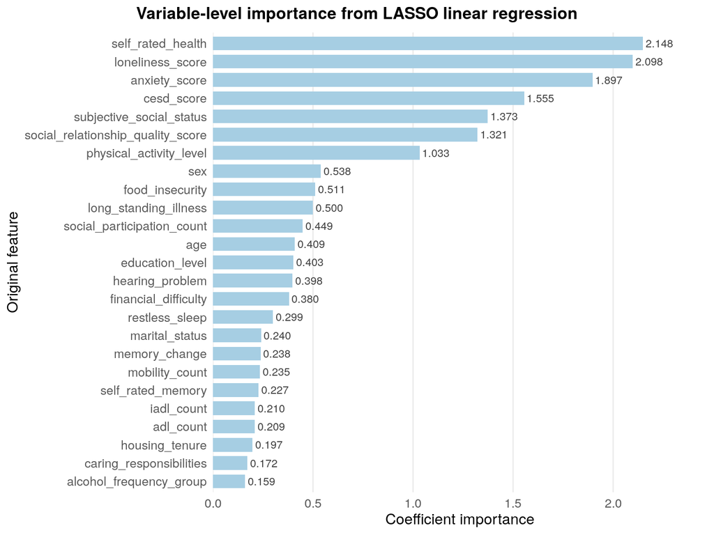

```r
# Plot the top 25 original features by linear LASSO coefficient importance.
lasso_lm_variable_importance_top25 <- lasso_lm_variable_importance %>%
  slice_head(n = 25) %>%
  mutate(
    original_feature = factor(original_feature, levels = rev(original_feature)),
    importance_label = sprintf("%.3f", coefficient_importance)
  )

lasso_linear_importance_plot <- ggplot(
  lasso_lm_variable_importance_top25,
  aes(
    x = original_feature,
    y = coefficient_importance
  )
) +
  geom_col(fill = "#A6CEE3", width = 0.75) +
  geom_text(
    aes(label = importance_label),
    hjust = -0.1,
    size = 3.1,
    color = "grey25"
  ) +
  scale_y_continuous(expand = expansion(mult = c(0, 0.15))) +
  coord_flip() +
  theme_minimal(base_size = 11) +
  theme(
    plot.title = element_text(
      hjust = 0.5,
      face = "bold",
      margin = margin(b = 8)
    ),
    plot.title.position = "plot",
    axis.title = element_text(size = 12, face = "plain", color = "black"),
    axis.text = element_text(size = 10, color = "grey35"),
    panel.grid.major.y = element_blank(),
    panel.grid.minor = element_blank(),
    legend.position = "none"
  ) +
  labs(
    title = "Variable-level importance from LASSO linear regression",
    x = "Original feature",
    y = "Coefficient importance"
  )

lasso_linear_importance_plot
```

```r
# Export the linear LASSO variable-level importance plot.
ggsave(
  filename = file.path(
    picture_path,
    "08_lasso_linear_variable_importance_top25.png"
  ),
  plot = lasso_linear_importance_plot,
  width = 8,
  height = 6,
  dpi = 300
)
```

# 6 6. Full-feature classification models

## 6.1 6.1 Full-feature Random Forest

```r
# Prepare the full-feature classification data using the 42 candidate predictors.
set.seed(123)

data11_train_cls <- data11_train %>%
  select(
    qol_status,
    all_of(candidate_features)
  ) %>%
  mutate(
    qol_status = case_when(
      as.character(qol_status) %in% c("Low QoL", "Low_QoL") ~ "Low_QoL",
      as.character(qol_status) %in% c("Non-low QoL", "Non_low_QoL") ~ "Non_low_QoL",
      TRUE ~ as.character(qol_status)
    ),
    qol_status = factor(qol_status, levels = c("Low_QoL", "Non_low_QoL")),
    across(where(is.ordered), ~ factor(.x, ordered = FALSE))
  )
```

```r
# Define the shared tree-model recipe, using one-hot dummy variables for algorithms that need numeric matrices.
tree_recipe <- recipe(qol_status ~ ., data = data11_train_cls) %>%
  step_impute_median(all_numeric_predictors()) %>%
  step_unknown(all_nominal_predictors(), new_level = "Missing") %>%
  step_novel(all_nominal_predictors(), new_level = "New") %>%
  step_dummy(all_nominal_predictors(), one_hot = TRUE) %>%
  step_zv(all_predictors())
```

```r
# Check how many predictors remain after dummy encoding and zero-variance filtering.
tree_recipe_prep <- prep(
  tree_recipe,
  training = data11_train_cls
)

rf_predictor_n <- bake(
  tree_recipe_prep,
  new_data = NULL
) %>%
  select(-qol_status) %>%
  ncol()

rf_predictor_n
```

```
## [1] 109
```

```r
# Create stratified folds so the low-QoL class is represented in each resample.
set.seed(123)

cv_folds <- vfold_cv(
  data11_train_cls,
  v = 10,
  strata = qol_status
)
```

```r
# Define the full-feature random forest and tune the main split and node-size parameters.
rf_model <- rand_forest(
  mode = "classification",
  trees = 500,
  mtry = tune(),
  min_n = tune()
) %>%
  set_engine(
    "ranger",
    importance = "impurity",
    probability = TRUE
  )
```

```r
# Combine the full-feature tree recipe and random-forest model into a workflow.
rf_workflow <- workflow() %>%
  add_recipe(tree_recipe) %>%
  add_model(rf_model)
```

```r
# Build a compact random-forest tuning grid for mtry and minimum node size.
set.seed(123)

rf_grid <- grid_regular(
  mtry(range = c(2, 20)),
  min_n(range = c(5, 30)),
  levels = 5
)
```

```r
# Tune the full-feature random forest on the training folds.
set.seed(123)

rf_tune <- tune_grid(
  rf_workflow,
  resamples = cv_folds,
  grid = rf_grid,
  metrics = classification_metrics
)
```

```r
# Collect the random-forest tuning results and pick the best ROC AUC setting.
rf_metrics <- collect_metrics(rf_tune)

best_rf <- select_best(
  rf_tune,
  metric = "roc_auc"
)

best_rf
```

```
## # A tibble: 1 × 3
##    mtry min_n .config
##   <int> <int> <chr>
## 1    11    17 Preprocessor1_Model13
```

```r
# Fit the final full-feature random forest on the complete training set.
final_rf_workflow <- finalize_workflow(
  rf_workflow,
  best_rf
)

set.seed(123)

final_rf_fit <- fit(
  final_rf_workflow,
  data = data11_train_cls
)
```

## 6.2 6.2 Full-feature XGBoost

```r
# Define the full-feature XGBoost model with its key hyperparameters exposed for tuning.
xgb_model <- boost_tree(
  mode = "classification",
  trees = tune(),
  tree_depth = tune(),
  learn_rate = tune(),
  loss_reduction = tune(),
  min_n = tune(),
  sample_size = tune(),
  mtry = tune()
) %>%
  set_engine("xgboost")
```

```r
# Combine the full-feature tree recipe and XGBoost model into a workflow.
xgb_workflow <- workflow() %>%
  add_recipe(tree_recipe) %>%
  add_model(xgb_model)
```

```r
# Use a space-filling grid to cover the XGBoost tuning space without making the search too large.
set.seed(123)

xgb_grid <- grid_space_filling(
  trees(range = c(200, 800)),
  tree_depth(range = c(2, 6)),
  learn_rate(range = c(-4, -1)),
  loss_reduction(range = c(-5, 1)),
  min_n(range = c(5, 30)),
  sample_size = sample_prop(range = c(0.6, 1.0)),
  finalize(mtry(), data11_train_cls %>% select(-qol_status)),
  size = 30
)
```

```r
# Tune the full-feature XGBoost model on the training folds.
set.seed(123)

xgb_tune <- tune_grid(
  xgb_workflow,
  resamples = cv_folds,
  grid = xgb_grid,
  metrics = classification_metrics
)
```

[output not shown]

[output not shown]

```r
# Collect XGBoost tuning results and select the best setting by ROC AUC.
xgb_metrics <- collect_metrics(xgb_tune)

best_xgb <- select_best(
  xgb_tune,
  metric = "roc_auc"
)

best_xgb
```

```
## # A tibble: 1 × 8
##    mtry trees min_n tree_depth learn_rate loss_reduction sample_size .config
##   <int> <int> <int>      <int>      <dbl>          <dbl>       <dbl> <chr>
## 1    26   220    24          6     0.0386       0.000728       0.766 Preprocess…
```

```r
# Fit the final full-feature XGBoost model using the selected hyperparameters.
final_xgb_workflow <- finalize_workflow(
  xgb_workflow,
  best_xgb
)

set.seed(123)

final_xgb_fit <- fit(
  final_xgb_workflow,
  data = data11_train_cls
)
```

## 6.3 6.3 XGBoost SHAP importance

```r
# Extract the fitted XGBoost engine and trained recipe for SHAP calculation.
xgb_engine <- extract_fit_engine(final_xgb_fit)

xgb_recipe <- extract_recipe(final_xgb_fit, estimated = TRUE)
```

```r
# Bake the training data through the fitted recipe so SHAP uses the same encoded predictors as the model.
xgb_train_processed <- bake(
  xgb_recipe,
  new_data = data11_train_cls
) %>%
  select(-qol_status)

xgb_train_matrix <- as.matrix(xgb_train_processed)
```

```r
# Calculate SHAP contributions on the encoded training matrix.
shap_contrib <- predict(
  xgb_engine,
  newdata = xgb_train_matrix,
  predcontrib = TRUE
)

if (is.null(colnames(shap_contrib))) {
  colnames(shap_contrib) <- c(colnames(xgb_train_matrix), "BIAS")
}

shap_values <- shap_contrib[, colnames(shap_contrib) != "BIAS", drop = FALSE]
```

```r
# Summarise mean absolute SHAP values for each encoded model term.
shap_importance_dummy <- as_tibble(shap_values) %>%
  summarise(
    across(
      everything(),
      ~ mean(abs(.x), na.rm = TRUE)
    )
  ) %>%
  pivot_longer(
    cols = everything(),
    names_to = "term",
    values_to = "mean_abs_shap"
  ) %>%
  arrange(desc(mean_abs_shap)) %>%
  mutate(rank = row_number()) %>%
  select(rank, term, mean_abs_shap)

shap_importance_dummy
```

```
## # A tibble: 109 × 3
##     rank term                                                 mean_abs_shap
##    <int> <chr>                                                        <dbl>
##  1     1 loneliness_score                                             0.553
##  2     2 anxiety_score                                                0.550
##  3     3 cesd_score                                                   0.487
##  4     4 social_relationship_quality_score                            0.411
##  5     5 subjective_social_status                                     0.248
##  6     6 social_participation_count                                   0.172
##  7     7 self_rated_health_Very.good                                  0.157
##  8     8 physical_activity_level_Vigorous.weekly                      0.147
##  9     9 long_standing_illness_Limiting.long.standing.illness         0.118
## 10    10 age                                                          0.115
## # ℹ 99 more rows
```

```r
# Map encoded dummy terms back to their original variables for feature-level SHAP summaries.
original_predictors <- setdiff(names(data11_train_cls), "qol_status")

map_original_feature <- function(term) {
  if (term %in% original_predictors) {
    return(term)
  }

  candidates <- original_predictors[
    map_lgl(
      original_predictors,
      ~ str_starts(term, paste0(.x, "_"))
    )
  ]

  if (length(candidates) == 0) {
    return(term)
  }

  candidates[which.max(nchar(candidates))]
}
```

```r
# Aggregate SHAP values from dummy terms to original predictor names.
shap_importance_feature <- shap_importance_dummy %>%
  mutate(
    original_feature = map_chr(term, map_original_feature)
  ) %>%
  group_by(original_feature) %>%
  summarise(
    mean_abs_shap = sum(mean_abs_shap),
    n_terms = n(),
    terms = paste(term, collapse = "; "),
    .groups = "drop"
  ) %>%
  arrange(desc(mean_abs_shap)) %>%
  mutate(rank = row_number()) %>%
  select(rank, original_feature, mean_abs_shap, n_terms, terms)

shap_importance_feature
```

```
## # A tibble: 42 × 5
##     rank original_feature                  mean_abs_shap n_terms terms
##    <int> <chr>                                     <dbl>   <int> <chr>
##  1     1 loneliness_score                          0.553       1 loneliness_sco…
##  2     2 anxiety_score                             0.550       1 anxiety_score
##  3     3 cesd_score                                0.487       1 cesd_score
##  4     4 social_relationship_quality_score         0.411       1 social_relatio…
##  5     5 self_rated_health                         0.293       5 self_rated_hea…
##  6     6 subjective_social_status                  0.248       1 subjective_soc…
##  7     7 physical_activity_level                   0.187       5 physical_activ…
##  8     8 sex                                       0.184       2 sex_Male; sex_…
##  9     9 social_participation_count                0.172       1 social_partici…
## 10    10 long_standing_illness                     0.157       3 long_standing_…
## # ℹ 32 more rows
```

```r
# Export the full-feature XGBoost SHAP importance results for audit and reporting.
write_xlsx(
  list(
    original_feature_importance = shap_importance_feature,
    encoded_term_importance = shap_importance_dummy
  ),
  file.path(output_path, "08_xgb_full_feature_shap_importance.xlsx")
)
```

[figure not shown]

```r
# Plot the top original predictors after SHAP values are aggregated across dummy terms.
### Original feature-level SHAP importance
xgb_shap_feature_importance_plot <- shap_importance_feature %>%
  slice_head(n = 20) %>%
  mutate(
    importance_label = sprintf("%.3f", mean_abs_shap)
  ) %>%
  ggplot(
    aes(
      x = reorder(original_feature, mean_abs_shap),
      y = mean_abs_shap
    )
  ) +
  geom_col(fill = "#F58518") +
  geom_text(
    aes(label = importance_label),
    hjust = -0.1,
    size = 3.1,
    color = "grey25"
  ) +
  scale_y_continuous(expand = expansion(mult = c(0, 0.15))) +
  coord_flip() +
  theme_minimal() +
  theme(
    plot.title = element_text(
      hjust = 0.5,
      face = "bold",
      margin = margin(b = 8)
    ),
    plot.title.position = "plot",
    axis.title = element_text(size = 12, face = "plain", color = "black"),
    axis.text = element_text(size = 10, color = "grey35")
  ) +
  labs(
    title = "Top 20 SHAP important original features: Full-feature XGBoost",
    x = "Original feature",
    y = "Aggregated mean absolute SHAP value"
  )

xgb_shap_feature_importance_plot
```

```r
# Export the XGBoost SHAP original-feature importance plot.
ggsave(
  filename = file.path(
    picture_path,
    "08_xgb_shap_original_feature_importance_top20.png"
  ),
  plot = xgb_shap_feature_importance_plot,
  width = 8,
  height = 6,
  dpi = 300
)
```

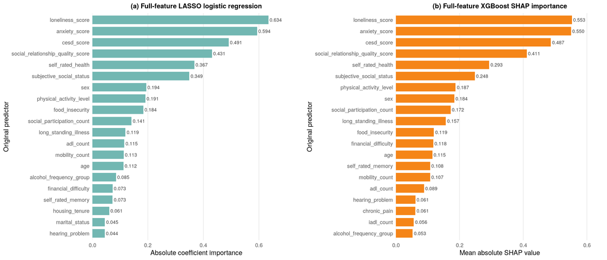

```r
# Combine logistic LASSO and full-feature XGBoost SHAP importance in one figure.
combined_lasso_importance <- lasso_variable_importance %>%
  slice_head(n = 20) %>%
  arrange(coefficient_importance) %>%
  mutate(
    original_feature = factor(original_feature, levels = original_feature),
    importance_label = sprintf("%.3f", coefficient_importance)
  )

combined_xgb_shap_importance <- shap_importance_feature %>%
  slice_head(n = 20) %>%
  arrange(mean_abs_shap) %>%
  mutate(
    original_feature = factor(original_feature, levels = original_feature),
    importance_label = sprintf("%.3f", mean_abs_shap)
  )

lasso_importance_panel <- ggplot(
  combined_lasso_importance,
  aes(
    x = original_feature,
    y = coefficient_importance
  )
) +
  geom_col(fill = "#72B7B2", width = 0.75) +
  geom_text(
    aes(label = importance_label),
    hjust = -0.1,
    size = 2.8,
    color = "grey25"
  ) +
  scale_y_continuous(expand = expansion(mult = c(0, 0.18))) +
  coord_flip() +
  theme_minimal(base_size = 11) +
  theme(
    plot.title = element_text(hjust = 0.5, face = "bold", size = 11),
    axis.title = element_text(size = 11),
    axis.text = element_text(size = 9, color = "grey35"),
    panel.grid.major.y = element_blank(),
    panel.grid.minor = element_blank()
  ) +
  labs(
    title = "(a) Full-feature LASSO logistic regression",
    x = "Original predictor",
    y = "Absolute coefficient importance"
  )

xgb_shap_importance_panel <- ggplot(
  combined_xgb_shap_importance,
  aes(
    x = original_feature,
    y = mean_abs_shap
  )
) +
  geom_col(fill = "#F58518", width = 0.75) +
  geom_text(
    aes(label = importance_label),
    hjust = -0.1,
    size = 2.8,
    color = "grey25"
  ) +
  scale_y_continuous(expand = expansion(mult = c(0, 0.18))) +
  coord_flip() +
  theme_minimal(base_size = 11) +
  theme(
    plot.title = element_text(hjust = 0.5, face = "bold", size = 11),
    axis.title = element_text(size = 11),
    axis.text = element_text(size = 9, color = "grey35"),
    panel.grid.major.y = element_blank(),
    panel.grid.minor = element_blank()
  ) +
  labs(
    title = "(b) Full-feature XGBoost SHAP importance",
    x = "Original predictor",
    y = "Mean absolute SHAP value"
  )

draw_lasso_xgb_importance_combined <- function() {
  grid.newpage()
  pushViewport(viewport(layout = grid.layout(nrow = 1, ncol = 2)))
  print(
    lasso_importance_panel,
    vp = viewport(layout.pos.row = 1, layout.pos.col = 1)
  )
  print(
    xgb_shap_importance_panel,
    vp = viewport(layout.pos.row = 1, layout.pos.col = 2)
  )
}

draw_lasso_xgb_importance_combined()
```

LASSO logistic regression used the binary low QoL outcome as the dependent variable. Continuous predictors were standardised before modelling. For categorical predictors, the absolute coefficients of all dummy variables were combined at the original variable level. A threshold of 0.10 was used as an operational selection criterion for both XGBoost SHAP and LASSO logistic regression. Variables with an importance value greater than 0.10 in either method were retained. The union of the variables identified by the two methods was used as the final important-feature set. This threshold provided a transparent and consistent rule for reducing the number of variables and was not intended as a criterion for statistical significance.

```r
# Export the combined LASSO logistic and XGBoost SHAP importance plot.
png(
  filename = file.path(
    picture_path,
    "08_lasso_logistic_and_xgb_shap_importance_top20_combined.png"
  ),
  width = 14,
  height = 6,
  units = "in",
  res = 300
)
draw_lasso_xgb_importance_combined()
dev.off()
```

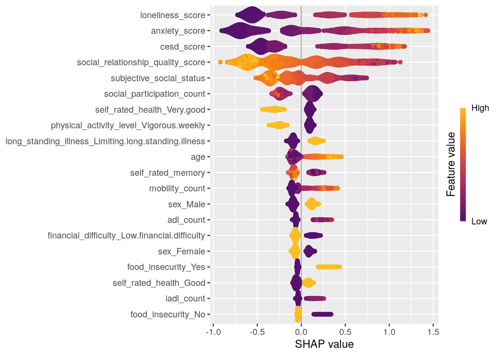

```r
# Create the SHAP beeswarm plot to show both importance and direction of prediction effects.
### SHAP beeswarm plot
shap_obj <- shapviz(
  xgb_engine,
  X_pred = xgb_train_matrix,
  X = as.data.frame(xgb_train_processed)
)

sv_importance(
  shap_obj,
  kind = "beeswarm",
  max_display = 20
)
```

```r
# Check that the SHAP output aligns with the model probability for Low_QoL.
shap_log_odds <- rowSums(shap_contrib)

shap_prob <- plogis(shap_log_odds)

xgb_prob_check <- predict(
  final_xgb_fit,
  new_data = data11_train_cls,
  type = "prob"
) %>%
  bind_cols(
    tibble(shap_prob = shap_prob)
  )

cor(
  xgb_prob_check$.pred_Low_QoL,
  xgb_prob_check$shap_prob,
  use = "complete.obs"
)
```

```
## [1] 1
```

```r
head(xgb_prob_check)
```

```
## # A tibble: 6 × 3
##   .pred_Low_QoL .pred_Non_low_QoL shap_prob
##           <dbl>             <dbl>     <dbl>
## 1         0.516             0.484     0.516
## 2         0.415             0.585     0.415
## 3         0.213             0.787     0.213
## 4         0.717             0.283     0.717
## 5         0.447             0.553     0.447
## 6         0.874             0.126     0.874
```

# 7 7. Models using the final 15 main features

## 7.1 7.1 Define the final 15 important predictors and build the important-feature dataset

The final 15 important predictors are fixed at this stage, after the full-feature models, LASSO-based predictor screening and XGBoost SHAP importance checks. The classification LASSO result is treated as the main reference because the main outcome is binary QoL status. LASSO linear regression and XGBoost SHAP are used as supporting evidence.

```r
# Fix the final 15 important predictors before building the reduced modelling dataset.
selected_main_features <- c(
  "loneliness_score",
  "anxiety_score",
  "cesd_score",
  "social_relationship_quality_score",
  "subjective_social_status",
  "self_rated_health",
  "sex",
  "food_insecurity",
  "physical_activity_level",
  "social_participation_count",
  "age",
  "long_standing_illness",
  "adl_count",
  "mobility_count",
  "financial_difficulty"
)

saveRDS(
  selected_main_features,
  file.path(processed_path, "08_main_features.rds")
)

selected_main_features
```

```
##  [1] "loneliness_score"                  "anxiety_score"
##  [3] "cesd_score"                        "social_relationship_quality_score"
##  [5] "subjective_social_status"          "self_rated_health"
##  [7] "sex"                               "food_insecurity"
##  [9] "physical_activity_level"           "social_participation_count"
## [11] "age"                               "long_standing_illness"
## [13] "adl_count"                         "mobility_count"
## [15] "financial_difficulty"
```

```r
# Create the important-feature dataset while keeping IDs and outcomes for later splitting.
data11_lasso_selected <- data11_training %>%
  select(
    idauniq,
    casp19_total,
    qol_status,
    all_of(selected_main_features)
  )

data11_lasso_selected
```

```
## # A tibble: 5,313 × 18
##    idauniq casp19_total qol_status  loneliness_score anxiety_score cesd_score
##      <dbl>        <dbl> <fct>                  <dbl>         <dbl>      <dbl>
##  1  104178           42 Non-low QoL                3             0          0
##  2  106612           50 Non-low QoL                3             0          0
##  3  104826           34 Low QoL                    4             2          1
##  4  105887           35 Low QoL                    6            10          0
##  5  107226           42 Non-low QoL               NA             0          1
##  6  108018           38 Non-low QoL                3             6          7
##  7  107507           27 Low QoL                    3             4         NA
##  8  104042           32 Low QoL                    4             5          1
##  9  107074           29 Low QoL                    3             0          2
## 10  107930           30 Low QoL                    5             0          2
## # ℹ 5,303 more rows
## # ℹ 12 more variables: social_relationship_quality_score <dbl>,
## #   subjective_social_status <dbl>, self_rated_health <ord>, sex <fct>,
## #   food_insecurity <fct>, physical_activity_level <ord>,
## #   social_participation_count <int>, age <dbl>, long_standing_illness <ord>,
## #   adl_count <int>, mobility_count <int>, financial_difficulty <ord>
```

```r
# Apply the original train-test split IDs to the important-feature dataset.
set.seed(123)
options(yardstick.event_first = TRUE)

data11_lasso_train <- data11_lasso_selected %>%
  filter(idauniq %in% data11_train$idauniq)
```

```r
# Prepare important-feature classification data with the same factor coding as the full-feature models.
data11_lasso_train_cls <- data11_lasso_train %>%
  mutate(
    qol_status = case_when(
      as.character(qol_status) %in% c("Low QoL", "Low_QoL") ~ "Low_QoL",
      as.character(qol_status) %in% c("Non-low QoL", "Non_low_QoL") ~ "Non_low_QoL",
      TRUE ~ as.character(qol_status)
    ),
    qol_status = factor(qol_status, levels = c("Low_QoL", "Non_low_QoL")),
    across(where(is.ordered), ~ factor(.x, ordered = FALSE))
  ) %>%
  select(
    -idauniq,
    -casp19_total
  )
```

```r
# Check outcome balance again after reducing to the final important predictors.
data11_lasso_train_cls %>%
  count(qol_status) %>%
  mutate(percent = round(n / sum(n) * 100, 2))
```

```
## # A tibble: 2 × 3
##   qol_status      n percent
##   <fct>       <int>   <dbl>
## 1 Low_QoL       940    25.3
## 2 Non_low_QoL  2778    74.7
```

```r
# Define the shared tree-model recipe, using one-hot dummy variables for algorithms that need numeric matrices.
selected_tree_recipe <- recipe(qol_status ~ ., data = data11_lasso_train_cls) %>%
  step_impute_median(all_numeric_predictors()) %>%
  step_unknown(all_nominal_predictors(), new_level = "Missing") %>%
  step_novel(all_nominal_predictors(), new_level = "New") %>%
  step_dummy(all_nominal_predictors(), one_hot = TRUE) %>%
  step_zv(all_predictors())
```

```r
# Check the encoded predictor count for the important-feature tree models.
selected_tree_recipe_prep <- prep(
  selected_tree_recipe,
  training = data11_lasso_train_cls
)

selected_predictor_data <- bake(
  selected_tree_recipe_prep,
  new_data = NULL
) %>%
  select(-qol_status)

selected_predictor_n <- ncol(selected_predictor_data)

selected_predictor_n
```

```
## [1] 30
```

```r
# Create stratified folds for the important-feature classification models.
set.seed(123)

cv_folds_selected <- vfold_cv(
  data11_lasso_train_cls,
  v = 10,
  strata = qol_status
)
```

## 7.2 7.2 Important-feature LASSO logistic regression

This model uses the same 15 important predictors as the important-feature RF, XGBoost, CatBoost and LightGBM models, so the later model comparison and ensemble analysis use a common predictor set.

```r
# Define the important-feature LASSO recipe for the reduced classification model.
lasso_selected_recipe <- recipe(qol_status ~ ., data = data11_lasso_train_cls) %>%
  step_impute_median(all_numeric_predictors()) %>%
  step_unknown(all_nominal_predictors(), new_level = "Missing") %>%
  step_novel(all_nominal_predictors(), new_level = "New") %>%
  step_dummy(all_nominal_predictors()) %>%
  step_zv(all_predictors()) %>%
  step_normalize(all_numeric_predictors())

lasso_selected_model <- logistic_reg(
  mode = "classification",
  penalty = tune(),
  mixture = 1
) %>%
  set_engine("glmnet")

lasso_selected_workflow <- workflow() %>%
  add_recipe(lasso_selected_recipe) %>%
  add_model(lasso_selected_model)
```

```r
# Use the same lambda range for the important-feature LASSO tuning step.
set.seed(123)

lasso_selected_grid <- grid_regular(
  penalty(range = c(-5, 0)),
  levels = 50
)

lasso_selected_tune <- tune_grid(
  lasso_selected_workflow,
  resamples = cv_folds_selected,
  grid = lasso_selected_grid,
  metrics = classification_metrics
)
```

[output not shown]

[output not shown]

```r
lasso_selected_metrics <- collect_metrics(lasso_selected_tune)

best_lasso_selected <- select_best(
  lasso_selected_tune,
  metric = "roc_auc"
)

best_lasso_selected
```

```
## # A tibble: 1 × 2
##   penalty .config
##     <dbl> <chr>
## 1 0.00222 Preprocessor1_Model24
```

```r
final_lasso_selected_workflow <- finalize_workflow(
  lasso_selected_workflow,
  best_lasso_selected
)

final_lasso_selected_fit <- fit(
  final_lasso_selected_workflow,
  data = data11_lasso_train_cls
)
```

## 7.3 7.3 Important-feature Random Forest

```r
# Define the important-feature random forest using the same tuning logic as the full-feature version.
rf_selected_model <- rand_forest(
  mode = "classification",
  trees = 500,
  mtry = tune(),
  min_n = tune()
) %>%
  set_engine(
    "ranger",
    importance = "impurity",
    probability = TRUE
  )
```

```r
# Combine the important-feature tree recipe and random-forest model into a workflow.
rf_selected_workflow <- workflow() %>%
  add_recipe(selected_tree_recipe) %>%
  add_model(rf_selected_model)
```

```r
# Create a smaller tuning grid suited to the reduced predictor set.
set.seed(123)

rf_selected_grid <- grid_regular(
  mtry(range = c(2, 20)),
  min_n(range = c(5, 30)),
  levels = 5
)
```

```r
# Tune the important-feature random forest.
set.seed(123)

rf_selected_tune <- tune_grid(
  rf_selected_workflow,
  resamples = cv_folds_selected,
  grid = rf_selected_grid,
  metrics = classification_metrics
)
```

```r
# Collect important-feature random-forest tuning metrics and select the best ROC AUC setting.
rf_selected_metrics <- collect_metrics(rf_selected_tune)

best_rf_selected <- select_best(
  rf_selected_tune,
  metric = "roc_auc"
)

best_rf_selected
```

```
## # A tibble: 1 × 3
##    mtry min_n .config
##   <int> <int> <chr>
## 1     6    11 Preprocessor1_Model07
```

```r
final_rf_selected_workflow <- finalize_workflow(
  rf_selected_workflow,
  best_rf_selected
)

set.seed(123)

final_rf_selected_fit <- fit(
  final_rf_selected_workflow,
  data = data11_lasso_train_cls
)
```

## 7.4 7.4 Important-feature XGBoost

```r
# Define the important-feature XGBoost model.
xgb_selected_model <- boost_tree(
  mode = "classification",
  trees = tune(),
  tree_depth = tune(),
  learn_rate = tune(),
  loss_reduction = tune(),
  min_n = tune(),
  sample_size = tune(),
  mtry = tune()
) %>%
  set_engine("xgboost")
```

```r
# Combine the important-feature tree recipe and XGBoost model into a workflow.
xgb_selected_workflow <- workflow() %>%
  add_recipe(selected_tree_recipe) %>%
  add_model(xgb_selected_model)
```

```r
# Build the important-feature XGBoost tuning grid.
set.seed(123)

xgb_selected_grid <- grid_space_filling(
  trees(range = c(200, 800)),
  tree_depth(range = c(2, 6)),
  learn_rate(range = c(-4, -1)),
  loss_reduction(range = c(-5, 1)),
  min_n(range = c(5, 30)),
  sample_size = sample_prop(range = c(0.6, 1.0)),
  finalize(mtry(), selected_predictor_data),
  size = 30
)
```

```r
# Tune the important-feature XGBoost model.
set.seed(123)

xgb_selected_tune <- tune_grid(
  xgb_selected_workflow,
  resamples = cv_folds_selected,
  grid = xgb_selected_grid,
  metrics = classification_metrics
)
```

```r
# Collect important-feature XGBoost tuning metrics and choose the best setting.
xgb_selected_metrics <- collect_metrics(xgb_selected_tune)

best_xgb_selected <- select_best(
  xgb_selected_tune,
  metric = "roc_auc"
)

best_xgb_selected
```

```
## # A tibble: 1 × 8
##    mtry trees min_n tree_depth learn_rate loss_reduction sample_size .config
##   <int> <int> <int>      <int>      <dbl>          <dbl>       <dbl> <chr>
## 1     6   386    21          3     0.0189      0.0000418       0.959 Preprocess…
```

```r
final_xgb_selected_workflow <- finalize_workflow(
  xgb_selected_workflow,
  best_xgb_selected
)

set.seed(123)

final_xgb_selected_fit <- fit(
  final_xgb_selected_workflow,
  data = data11_lasso_train_cls
)
```

# 8 8. CatBoost models

## 8.1 8.1 CatBoost helper functions

```r
# Reset the shared classification settings before moving into the CatBoost section.
set.seed(123)

options(yardstick.event_first = TRUE)
```

```r
# Define the CatBoost data-preparation helper, keeping categorical variables in a form CatBoost can handle natively.
prepare_catboost_data <- function(train_data, test_data, outcome = "qol_status") {

  train_data <- train_data %>%
    mutate(
      !!outcome := case_when(
        as.character(.data[[outcome]]) %in% c("Low QoL", "Low_QoL") ~ "Low_QoL",
        as.character(.data[[outcome]]) %in% c("Non-low QoL", "Non_low_QoL") ~ "Non_low_QoL",
        TRUE ~ as.character(.data[[outcome]])
      ),
      !!outcome := factor(.data[[outcome]], levels = c("Low_QoL", "Non_low_QoL")),
      across(where(is.ordered), ~ factor(.x, ordered = FALSE))
    )

  test_data <- test_data %>%
    mutate(
      !!outcome := case_when(
        as.character(.data[[outcome]]) %in% c("Low QoL", "Low_QoL") ~ "Low_QoL",
        as.character(.data[[outcome]]) %in% c("Non-low QoL", "Non_low_QoL") ~ "Non_low_QoL",
        TRUE ~ as.character(.data[[outcome]])
      ),
      !!outcome := factor(.data[[outcome]], levels = c("Low_QoL", "Non_low_QoL")),
      across(where(is.ordered), ~ factor(.x, ordered = FALSE))
    )

  predictor_names <- setdiff(names(train_data), outcome)

  numeric_vars <- train_data %>%
    select(all_of(predictor_names)) %>%
    select(where(is.numeric)) %>%
    names()

  categorical_vars <- train_data %>%
    select(all_of(predictor_names)) %>%
    select(where(~ is.factor(.x) || is.character(.x))) %>%
    names()

  train_medians <- train_data %>%
    summarise(
      across(
        all_of(numeric_vars),
        ~ median(.x, na.rm = TRUE)
      )
    )

  for (v in numeric_vars) {
    med_v <- train_medians[[v]]
    train_data[[v]][is.na(train_data[[v]])] <- med_v
    test_data[[v]][is.na(test_data[[v]])] <- med_v
  }

  for (v in categorical_vars) {
    train_data[[v]] <- as.factor(train_data[[v]])
    test_data[[v]] <- as.factor(test_data[[v]])

    train_data[[v]] <- fct_na_value_to_level(train_data[[v]], level = "Missing")
    test_data[[v]] <- fct_na_value_to_level(test_data[[v]], level = "Missing")

    train_levels <- levels(train_data[[v]])
    train_levels <- union(train_levels, c("Missing", "New"))

    train_data[[v]] <- factor(as.character(train_data[[v]]), levels = train_levels)

    test_chr <- as.character(test_data[[v]])
    test_chr[!(test_chr %in% train_levels)] <- "New"
    test_data[[v]] <- factor(test_chr, levels = train_levels)
  }

  list(
    train = train_data,
    test = test_data
  )
}
```

```r
# Tune CatBoost manually because it is fitted outside the tidymodels workflow used above.
# Hyperparameters are selected using training-set stratified 10-fold cross-validation,
# matching the validation strategy used for the other main machine-learning models.
tune_catboost <- function(train_data, outcome = "qol_status", grid_size = 15, n_folds = 10) {

  set.seed(123)

  cat_folds <- vfold_cv(
    train_data,
    v = n_folds,
    strata = all_of(outcome)
  )

  fold_data <- map(
    seq_along(cat_folds$splits),
    function(fold_i) {
      cat_inner_data <- prepare_catboost_data(
        train_data = analysis(cat_folds$splits[[fold_i]]),
        test_data = assessment(cat_folds$splits[[fold_i]]),
        outcome = outcome
      )

      cat_inner_train <- cat_inner_data$train
      cat_inner_valid <- cat_inner_data$test

      x_train <- cat_inner_train %>% select(-all_of(outcome))
      y_train <- if_else(cat_inner_train[[outcome]] == "Low_QoL", 1, 0)

      x_valid <- cat_inner_valid %>% select(-all_of(outcome))
      y_valid <- if_else(cat_inner_valid[[outcome]] == "Low_QoL", 1, 0)

      list(
        fold = fold_i,
        train_pool = catboost.load_pool(
          data = x_train,
          label = y_train
        ),
        valid_pool = catboost.load_pool(
          data = x_valid,
          label = y_valid
        ),
        y_valid = y_valid,
        n_train = nrow(cat_inner_train),
        n_validation = nrow(cat_inner_valid)
      )
    }
  )

  set.seed(123)

  param_grid <- tibble(
    iterations = sample(seq(300, 800, by = 100), grid_size, replace = TRUE),
    depth = sample(3:6, grid_size, replace = TRUE),
    learning_rate = runif(grid_size, 0.01, 0.10),
    l2_leaf_reg = sample(c(1, 3, 5, 7, 10), grid_size, replace = TRUE),
    random_strength = sample(c(1, 2, 5, 10), grid_size, replace = TRUE)
  )

  tuning_results <- map_dfr(
    seq_len(nrow(param_grid)),
    function(i) {

      params <- list(
        loss_function = "Logloss",
        eval_metric = "AUC",
        iterations = param_grid$iterations[i],
        depth = param_grid$depth[i],
        learning_rate = param_grid$learning_rate[i],
        l2_leaf_reg = param_grid$l2_leaf_reg[i],
        random_strength = param_grid$random_strength[i],
        use_best_model = FALSE,
        random_seed = 123,
        thread_count = 4,
        logging_level = "Silent",
        allow_writing_files = FALSE
      )

      fold_results <- map_dfr(
        fold_data,
        function(fold_i) {
          model_i <- catboost.train(
            learn_pool = fold_i$train_pool,
            test_pool = fold_i$valid_pool,
            params = params
          )

          pred_raw <- catboost.predict(
            model_i,
            fold_i$valid_pool,
            prediction_type = "Probability"
          )

          pred_prob <- as.numeric(pred_raw)

          valid_pred <- tibble(
            truth = factor(
              if_else(fold_i$y_valid == 1, "Low_QoL", "Non_low_QoL"),
              levels = c("Low_QoL", "Non_low_QoL")
            ),
            .pred_Low_QoL = pred_prob
          )

          auc_i <- valid_pred %>%
            roc_auc(
              truth = truth,
              .pred_Low_QoL,
              event_level = "first"
            ) %>%
            pull(.estimate)

          pr_auc_i <- valid_pred %>%
            pr_auc(
              truth = truth,
              .pred_Low_QoL,
              event_level = "first"
            ) %>%
            pull(.estimate)

          rm(model_i)
          gc(verbose = FALSE)

          tibble(
            fold = fold_i$fold,
            roc_auc = auc_i,
            pr_auc = pr_auc_i,
            n_train = fold_i$n_train,
            n_validation = fold_i$n_validation
          )
        }
      )

      bind_cols(
        param_grid[i, ],
        fold_results %>%
          summarise(
            roc_auc = mean(roc_auc, na.rm = TRUE),
            pr_auc = mean(pr_auc, na.rm = TRUE),
            roc_auc_sd = sd(roc_auc, na.rm = TRUE),
            pr_auc_sd = sd(pr_auc, na.rm = TRUE),
            n_folds = n()
          )
      )
    }
  )

  best_params <- tuning_results %>%
    arrange(desc(roc_auc)) %>%
    slice_head(n = 1)

  list(
    tuning_results = tuning_results,
    best_params = best_params
  )
}
```

## 8.2 8.2 Full-feature CatBoost

```r
# Prepare the full-feature CatBoost training object.
cat_full_train_raw <- data11_train %>%
  select(
    qol_status,
    all_of(candidate_features)
  ) %>%
  mutate(
    across(where(is.ordered), ~ factor(.x, ordered = FALSE))
  )

cat_full_data <- prepare_catboost_data(
  train_data = cat_full_train_raw,
  test_data = cat_full_train_raw,
  outcome = "qol_status"
)

cat_full_train <- cat_full_data$train
```

```r
# Tune the full-feature CatBoost model on the training data.
set.seed(123)

cat_full_tune <- tune_catboost(
  train_data = cat_full_train_raw,
  outcome = "qol_status",
  grid_size = 15,
  n_folds = 10
)

cat_full_tune$tuning_results
```

```
## # A tibble: 15 × 10
##    iterations depth learning_rate l2_leaf_reg random_strength roc_auc pr_auc
##         <dbl> <int>         <dbl>       <dbl>           <dbl>   <dbl>  <dbl>
##  1        500     5        0.0816           5               1   0.913  0.803
##  2        800     5        0.0122           7               2   0.917  0.813
##  3        500     3        0.0530          10               1   0.917  0.813
##  4        400     6        0.0783          10               5   0.915  0.808
##  5        400     3        0.0295           5               1   0.917  0.812
##  6        800     3        0.0386           1               5   0.918  0.814
##  7        500     3        0.0308           3               2   0.918  0.814
##  8        700     5        0.0229          10              10   0.917  0.813
##  9        600     6        0.0473          10               5   0.915  0.810
## 10        800     4        0.0472           7              10   0.917  0.811
## 11        800     5        0.0432          10              10   0.917  0.813
## 12        300     4        0.0237           3               2   0.917  0.813
## 13        400     3        0.0225           1               2   0.916  0.811
## 14        500     4        0.0310           1               5   0.918  0.815
## 15        700     5        0.0519           5              10   0.916  0.812
## # ℹ 3 more variables: roc_auc_sd <dbl>, pr_auc_sd <dbl>, n_folds <int>
```

```r
cat_full_tune$best_params
```

```
## # A tibble: 1 × 10
##   iterations depth learning_rate l2_leaf_reg random_strength roc_auc pr_auc
##        <dbl> <int>         <dbl>       <dbl>           <dbl>   <dbl>  <dbl>
## 1        500     4        0.0310           1               5   0.918  0.815
## # ℹ 3 more variables: roc_auc_sd <dbl>, pr_auc_sd <dbl>, n_folds <int>
```

```r
# Create CatBoost pools for the final full-feature model fit.
cat_full_x_train <- cat_full_train %>% select(-qol_status)

cat_full_y_train <- if_else(cat_full_train$qol_status == "Low_QoL", 1, 0)

cat_full_train_pool <- catboost.load_pool(
  data = cat_full_x_train,
  label = cat_full_y_train
)

best_full_params <- cat_full_tune$best_params

cat_full_params <- list(
  loss_function = "Logloss",
  eval_metric = "AUC",
  iterations = best_full_params$iterations,
  depth = best_full_params$depth,
  learning_rate = best_full_params$learning_rate,
  l2_leaf_reg = best_full_params$l2_leaf_reg,
  random_strength = best_full_params$random_strength,
  use_best_model = FALSE,
  random_seed = 123,
  thread_count = 4,
  logging_level = "Silent",
  allow_writing_files = FALSE
)

final_cat_full_fit <- catboost.train(
  learn_pool = cat_full_train_pool,
  test_pool = NULL,
  params = cat_full_params
)
```

## 8.3 8.3 Important-feature CatBoost

```r
# Build the important-feature raw data frame for CatBoost.
cat_selected_train_raw <- data11_lasso_selected %>%
  filter(idauniq %in% data11_train$idauniq) %>%
  select(
    -idauniq,
    -casp19_total
  )

cat_selected_data <- prepare_catboost_data(
  train_data = cat_selected_train_raw,
  test_data = cat_selected_train_raw,
  outcome = "qol_status"
)

cat_selected_train <- cat_selected_data$train
```

```r
# Tune the important-feature CatBoost model.
set.seed(123)

cat_selected_tune <- tune_catboost(
  train_data = cat_selected_train_raw,
  outcome = "qol_status",
  grid_size = 15,
  n_folds = 10
)

cat_selected_tune$tuning_results
```

```
## # A tibble: 15 × 10
##    iterations depth learning_rate l2_leaf_reg random_strength roc_auc pr_auc
##         <dbl> <int>         <dbl>       <dbl>           <dbl>   <dbl>  <dbl>
##  1        500     5        0.0816           5               1   0.912  0.800
##  2        800     5        0.0122           7               2   0.918  0.815
##  3        500     3        0.0530          10               1   0.919  0.813
##  4        400     6        0.0783          10               5   0.915  0.807
##  5        400     3        0.0295           5               1   0.919  0.814
##  6        800     3        0.0386           1               5   0.918  0.812
##  7        500     3        0.0308           3               2   0.919  0.813
##  8        700     5        0.0229          10              10   0.918  0.815
##  9        600     6        0.0473          10               5   0.915  0.807
## 10        800     4        0.0472           7              10   0.916  0.807
## 11        800     5        0.0432          10              10   0.915  0.807
## 12        300     4        0.0237           3               2   0.918  0.814
## 13        400     3        0.0225           1               2   0.918  0.814
## 14        500     4        0.0310           1               5   0.919  0.814
## 15        700     5        0.0519           5              10   0.913  0.804
## # ℹ 3 more variables: roc_auc_sd <dbl>, pr_auc_sd <dbl>, n_folds <int>
```

```r
cat_selected_tune$best_params
```

```
## # A tibble: 1 × 10
##   iterations depth learning_rate l2_leaf_reg random_strength roc_auc pr_auc
##        <dbl> <int>         <dbl>       <dbl>           <dbl>   <dbl>  <dbl>
## 1        500     3        0.0530          10               1   0.919  0.813
## # ℹ 3 more variables: roc_auc_sd <dbl>, pr_auc_sd <dbl>, n_folds <int>
```

```r
# Create CatBoost pools for the important-feature final fit.
cat_selected_x_train <- cat_selected_train %>% select(-qol_status)
cat_selected_y_train <- if_else(cat_selected_train$qol_status == "Low_QoL", 1, 0)

cat_selected_train_pool <- catboost.load_pool(
  data = cat_selected_x_train,
  label = cat_selected_y_train
)

best_selected_params <- cat_selected_tune$best_params

cat_selected_params <- list(
  loss_function = "Logloss",
  eval_metric = "AUC",
  iterations = best_selected_params$iterations,
  depth = best_selected_params$depth,
  learning_rate = best_selected_params$learning_rate,
  l2_leaf_reg = best_selected_params$l2_leaf_reg,
  random_strength = best_selected_params$random_strength,
  use_best_model = FALSE,
  random_seed = 123,
  thread_count = 4,
  logging_level = "Silent",
  allow_writing_files = FALSE
)

final_cat_selected_fit <- catboost.train(
  learn_pool = cat_selected_train_pool,
  test_pool = NULL,
  params = cat_selected_params
)
```

# 9 9. LightGBM models

```r
# Wrap the LightGBM workflow in a helper so the full and important-feature runs stay comparable.
develop_lightgbm_model <- function(train_data, model_name, grid_size = 30) {

  train_data <- train_data %>%
    mutate(
      qol_status = case_when(
        as.character(qol_status) %in% c("Low QoL", "Low_QoL") ~ "Low_QoL",
        as.character(qol_status) %in% c("Non-low QoL", "Non_low_QoL") ~ "Non_low_QoL",
        TRUE ~ as.character(qol_status)
      ),
      qol_status = factor(qol_status, levels = c("Low_QoL", "Non_low_QoL"))
    ) %>%
    select(-any_of("casp19_total"))

  lgbm_recipe <- recipe(qol_status ~ ., data = train_data) %>%
    step_impute_median(all_numeric_predictors()) %>%
    step_unknown(all_nominal_predictors(), new_level = "Missing") %>%
    step_novel(all_nominal_predictors(), new_level = "New") %>%
    step_dummy(all_nominal_predictors(), one_hot = TRUE) %>%
    step_zv(all_predictors())

  set.seed(123)

  lgbm_folds <- vfold_cv(
    train_data,
    v = 10,
    strata = qol_status
  )

  lgbm_model <- boost_tree(
    mode = "classification",
    trees = tune(),
    tree_depth = tune(),
    learn_rate = tune(),
    loss_reduction = tune(),
    min_n = tune(),
    sample_size = tune()
  ) %>%
    set_engine("lightgbm")

  lgbm_workflow <- workflow() %>%
    add_recipe(lgbm_recipe) %>%
    add_model(lgbm_model)

  set.seed(123)

  lgbm_grid <- grid_space_filling(
    trees(range = c(200, 800)),
    tree_depth(range = c(2, 6)),
    learn_rate(range = c(-4, -1)),
    loss_reduction(range = c(-5, 1)),
    min_n(range = c(5, 30)),
    sample_size = sample_prop(range = c(0.6, 1.0)),
    size = grid_size
  )

  set.seed(123)

  lgbm_tune <- tune_grid(
    lgbm_workflow,
    resamples = lgbm_folds,
    grid = lgbm_grid,
    metrics = classification_metrics
  )

  lgbm_tuning_metrics <- collect_metrics(lgbm_tune)

  best_lgbm <- select_best(
    lgbm_tune,
    metric = "roc_auc"
  )

  final_lgbm_workflow <- finalize_workflow(
    lgbm_workflow,
    best_lgbm
  )

  set.seed(123)

  final_lgbm_fit <- fit(
    final_lgbm_workflow,
    data = train_data
  )

  list(
    model_name = model_name,
    best_params = best_lgbm,
    tuning_metrics = lgbm_tuning_metrics,
    fit = final_lgbm_fit
  )
}
```

## 9.1 9.1 Full-feature LightGBM

```r
# Run the LightGBM helper on the full-feature dataset.
set.seed(123)

lgbm_full_result <- develop_lightgbm_model(
  train_data = data11_train_cls,
  model_name = "Full-feature LightGBM (42)",
  grid_size = 30
)
```

[output not shown]

[output not shown]

```r
lgbm_full_result$best_params
```

```
## # A tibble: 1 × 7
##   trees min_n tree_depth learn_rate loss_reduction sample_size .config
##   <int> <int>      <int>      <dbl>          <dbl>       <dbl> <chr>
## 1   468    19          2     0.0489           3.86       0.766 Preprocessor1_Mo…
```

## 9.2 9.2 Important-feature LightGBM

```r
# Run the same LightGBM helper on the important-feature dataset.
set.seed(123)

lgbm_selected_result <- develop_lightgbm_model(
  train_data = data11_lasso_train_cls,
  model_name = "Important-feature LightGBM (15)",
  grid_size = 30
)
```

[output not shown]

[output not shown]

```r
lgbm_selected_result$best_params
```

```
## # A tibble: 1 × 7
##   trees min_n tree_depth learn_rate loss_reduction sample_size .config
##   <int> <int>      <int>      <dbl>          <dbl>       <dbl> <chr>
## 1   468    19          2     0.0489           3.86       0.766 Preprocessor1_Mo…
```

## 9.3 9.3 Important-feature LightGBM SHAP bar plot

The SHAP bar plot below ranks the final 15 selected predictors by their mean absolute contribution to the important-feature LightGBM model. This shows the relative model relevance of each predictor, rather than a causal correlation.

```r
# Extract the fitted LightGBM engine and trained preprocessing recipe.
lgbm_selected_engine <- extract_fit_engine(lgbm_selected_result$fit)

lgbm_selected_recipe <- extract_recipe(
  lgbm_selected_result$fit,
  estimated = TRUE
)
```

```r
# Bake the important-feature training data so SHAP uses the exact encoded inputs used by LightGBM.
lgbm_selected_train_processed <- bake(
  lgbm_selected_recipe,
  new_data = data11_lasso_train_cls
) %>%
  select(-qol_status)

lgbm_selected_train_matrix <- as.matrix(lgbm_selected_train_processed)
storage.mode(lgbm_selected_train_matrix) <- "double"
```

```r
# Calculate LightGBM SHAP contributions on the important-feature training matrix.
lgbm_selected_shap_contrib <- predict(
  lgbm_selected_engine,
  newdata = lgbm_selected_train_matrix,
  type = "contrib"
)

lgbm_selected_shap_contrib <- as.matrix(lgbm_selected_shap_contrib)

if (ncol(lgbm_selected_shap_contrib) == ncol(lgbm_selected_train_matrix) + 1) {
  colnames(lgbm_selected_shap_contrib) <- c(
    colnames(lgbm_selected_train_matrix),
    "BIAS"
  )

  lgbm_selected_shap_values <- lgbm_selected_shap_contrib[
    ,
    seq_len(ncol(lgbm_selected_train_matrix)),
    drop = FALSE
  ]
} else if (ncol(lgbm_selected_shap_contrib) == ncol(lgbm_selected_train_matrix)) {
  colnames(lgbm_selected_shap_contrib) <- colnames(lgbm_selected_train_matrix)
  lgbm_selected_shap_values <- lgbm_selected_shap_contrib
} else {
  stop(
    "Unexpected number of SHAP contribution columns from LightGBM: ",
    ncol(lgbm_selected_shap_contrib)
  )
}
```

```r
# Summarise mean absolute SHAP values for each encoded LightGBM model term.
lgbm_selected_shap_importance_dummy <- as_tibble(
  lgbm_selected_shap_values,
  .name_repair = "minimal"
) %>%
  summarise(
    across(
      everything(),
      ~ mean(abs(.x), na.rm = TRUE)
    )
  ) %>%
  pivot_longer(
    cols = everything(),
    names_to = "term",
    values_to = "mean_abs_shap"
  ) %>%
  arrange(desc(mean_abs_shap)) %>%
  mutate(rank = row_number()) %>%
  select(rank, term, mean_abs_shap)

lgbm_selected_shap_importance_dummy
```

```
## # A tibble: 30 × 3
##     rank term                                    mean_abs_shap
##    <int> <chr>                                           <dbl>
##  1     1 anxiety_score                                   0.557
##  2     2 loneliness_score                                0.546
##  3     3 cesd_score                                      0.486
##  4     4 social_relationship_quality_score               0.391
##  5     5 self_rated_health_Very.good                     0.284
##  6     6 subjective_social_status                        0.277
##  7     7 social_participation_count                      0.199
##  8     8 sex_Male                                        0.190
##  9     9 physical_activity_level_Vigorous.weekly         0.177
## 10    10 self_rated_health_Excellent                     0.174
## # ℹ 20 more rows
```

```r
# Map one-hot encoded terms back to the original 15 selected feature names.
lgbm_selected_original_predictors <- selected_main_features

map_lgbm_selected_original_feature <- function(term) {
  if (term %in% lgbm_selected_original_predictors) {
    return(term)
  }

  candidates <- lgbm_selected_original_predictors[
    map_lgl(
      lgbm_selected_original_predictors,
      ~ str_starts(term, paste0(.x, "_"))
    )
  ]

  if (length(candidates) == 0) {
    return(term)
  }

  candidates[which.max(nchar(candidates))]
}
```

```r
# Aggregate dummy-level SHAP values to the original important-feature level.
lgbm_selected_shap_importance_feature <- lgbm_selected_shap_importance_dummy %>%
  mutate(
    original_feature = map_chr(term, map_lgbm_selected_original_feature)
  ) %>%
  group_by(original_feature) %>%
  summarise(
    mean_abs_shap = sum(mean_abs_shap),
    n_terms = n(),
    terms = paste(term, collapse = "; "),
    .groups = "drop"
  ) %>%
  right_join(
    tibble(original_feature = selected_main_features),
    by = "original_feature"
  ) %>%
  mutate(
    mean_abs_shap = replace_na(mean_abs_shap, 0),
    n_terms = replace_na(n_terms, 0L),
    terms = replace_na(terms, "No encoded terms after preprocessing")
  ) %>%
  arrange(desc(mean_abs_shap)) %>%
  mutate(rank = row_number()) %>%
  select(rank, original_feature, mean_abs_shap, n_terms, terms)

saveRDS(
  lgbm_selected_shap_importance_feature,
  file.path(processed_path, "08_lightgbm_selected_shap_feature_importance.rds")
)

lgbm_selected_shap_importance_feature
```

```
## # A tibble: 15 × 5
##     rank original_feature                  mean_abs_shap n_terms terms
##    <int> <chr>                                     <dbl>   <int> <chr>
##  1     1 anxiety_score                            0.557        1 anxiety_score
##  2     2 loneliness_score                         0.546        1 loneliness_sco…
##  3     3 self_rated_health                        0.506        5 self_rated_hea…
##  4     4 cesd_score                               0.486        1 cesd_score
##  5     5 social_relationship_quality_score        0.391        1 social_relatio…
##  6     6 subjective_social_status                 0.277        1 subjective_soc…
##  7     7 physical_activity_level                  0.214        5 physical_activ…
##  8     8 social_participation_count               0.199        1 social_partici…
##  9     9 sex                                      0.192        2 sex_Male; sex_…
## 10    10 age                                      0.141        1 age
## 11    11 long_standing_illness                    0.112        3 long_standing_…
## 12    12 mobility_count                           0.107        1 mobility_count
## 13    13 financial_difficulty                     0.0995       4 financial_diff…
## 14    14 food_insecurity                          0.0929       2 food_insecurit…
## 15    15 adl_count                                0.0924       1 adl_count
```

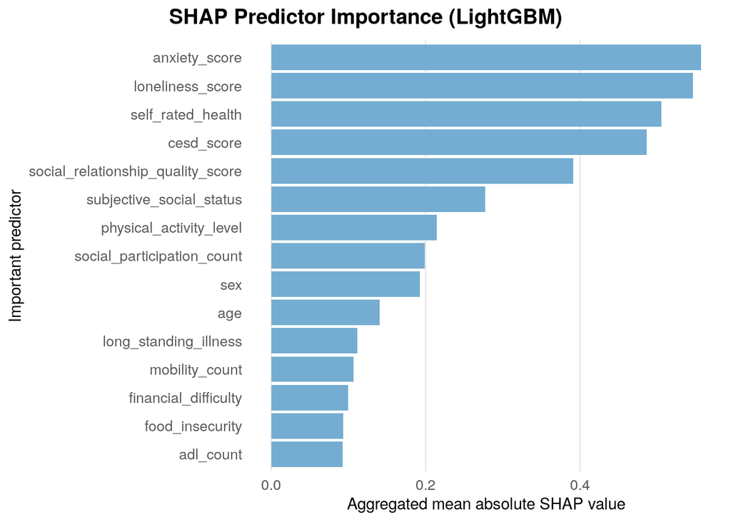

```r
# Plot the 15 important predictors by aggregated mean absolute SHAP value.
lgbm_selected_shap_feature_importance_plot <- lgbm_selected_shap_importance_feature %>%
  ggplot(
    aes(
      x = reorder(original_feature, mean_abs_shap),
      y = mean_abs_shap
    )
  ) +
  geom_col(fill = "#74ADD1") +
  coord_flip() +
  theme_minimal(base_size = 12) +
  theme(
    plot.title = element_text(
      hjust = 0.5,
      face = "bold",
      margin = margin(b = 8)
    ),
    plot.title.position = "plot",
    panel.grid.major.y = element_blank(),
    panel.grid.minor = element_blank(),
    axis.title = element_text(size = 11, face = "plain", color = "black"),
    axis.text = element_text(size = 10, color = "grey35")
  ) +
  labs(
    title = "SHAP Predictor Importance (LightGBM)",
    x = "Important predictor",
    y = "Aggregated mean absolute SHAP value"
  )

lgbm_selected_shap_feature_importance_plot
```

```r
# Export the LightGBM important-feature SHAP bar plot.
ggsave(
  filename = file.path(
    picture_path,
    "08_lightgbm_selected_shap_feature_importance_top15.png"
  ),
  plot = lgbm_selected_shap_feature_importance_plot,
  width = 8,
  height = 5.5,
  dpi = 300
)
```

# 10 10. MLP models

## 10.1 10.1 Full-feature MLP

```r
# Define the full-feature MLP recipe with scaling before dummy encoding.
mlp_full_recipe <- recipe(qol_status ~ ., data = data11_train_cls) %>%
  step_impute_median(all_numeric_predictors()) %>%
  step_unknown(all_nominal_predictors(), new_level = "Missing") %>%
  step_novel(all_nominal_predictors(), new_level = "New") %>%
  step_normalize(all_numeric_predictors()) %>%
  step_dummy(all_nominal_predictors(), one_hot = TRUE) %>%
  step_zv(all_predictors())
```

```r
# Set up the MLP model and tune hidden units, regularisation, and epochs.
mlp_model <- mlp(
  mode = "classification",
  hidden_units = tune(),
  penalty = tune(),
  epochs = tune()
) %>%
  set_engine(
    "nnet",
    trace = FALSE,
    MaxNWts = 50000
  )
```

```r
# Combine the full-feature MLP recipe and neural-network model into a workflow.
mlp_full_workflow <- workflow() %>%
  add_recipe(mlp_full_recipe) %>%
  add_model(mlp_model)
```

```r
# Create stratified folds for MLP tuning.
set.seed(123)

cv_folds_mlp <- vfold_cv(
  data11_train_cls,
  v = 10,
  strata = qol_status
)
```

```r
# Use a small MLP grid to keep neural-network tuning manageable.
mlp_grid <- expand_grid(
  hidden_units = c(3, 5, 10),
  penalty = c(0.0001, 0.001, 0.01),
  epochs = c(100, 200)
)

mlp_grid
```

```
## # A tibble: 18 × 3
##    hidden_units penalty epochs
##           <dbl>   <dbl>  <dbl>
##  1            3  0.0001    100
##  2            3  0.0001    200
##  3            3  0.001     100
##  4            3  0.001     200
##  5            3  0.01      100
##  6            3  0.01      200
##  7            5  0.0001    100
##  8            5  0.0001    200
##  9            5  0.001     100
## 10            5  0.001     200
## 11            5  0.01      100
## 12            5  0.01      200
## 13           10  0.0001    100
## 14           10  0.0001    200
## 15           10  0.001     100
## 16           10  0.001     200
## 17           10  0.01      100
## 18           10  0.01      200
```

```r
# Tune the full-feature MLP.
set.seed(123)

mlp_full_tune <- tune_grid(
  mlp_full_workflow,
  resamples = cv_folds_mlp,
  grid = mlp_grid,
  metrics = classification_metrics
)
```

[output not shown]

[output not shown]

```r
# Collect full-feature MLP tuning metrics and select the best ROC AUC setting.
mlp_full_metrics <- collect_metrics(mlp_full_tune)

best_mlp_full <- select_best(
  mlp_full_tune,
  metric = "roc_auc"
)

best_mlp_full
```

```
## # A tibble: 1 × 4
##   hidden_units penalty epochs .config
##          <dbl>   <dbl>  <dbl> <chr>
## 1            3    0.01    100 Preprocessor1_Model05
```

```r
final_mlp_full_workflow <- finalize_workflow(
  mlp_full_workflow,
  best_mlp_full
)

set.seed(123)

final_mlp_full_fit <- fit(
  final_mlp_full_workflow,
  data = data11_train_cls
)
```

## 10.2 10.2 Important-feature MLP

```r
# Define the important-feature MLP recipe using the reduced predictor set.
mlp_selected_recipe <- recipe(qol_status ~ ., data = data11_lasso_train_cls) %>%
  step_impute_median(all_numeric_predictors()) %>%
  step_unknown(all_nominal_predictors(), new_level = "Missing") %>%
  step_novel(all_nominal_predictors(), new_level = "New") %>%
  step_normalize(all_numeric_predictors()) %>%
  step_dummy(all_nominal_predictors(), one_hot = TRUE) %>%
  step_zv(all_predictors())
```

```r
# Combine the important-feature MLP recipe and model.
mlp_selected_workflow <- workflow() %>%
  add_recipe(mlp_selected_recipe) %>%
  add_model(mlp_model)
```

```r
# Create stratified folds for important-feature MLP tuning.
set.seed(123)

cv_folds_mlp_selected <- vfold_cv(
  data11_lasso_train_cls,
  v = 10,
  strata = qol_status
)
```

```r
# Tune the important-feature MLP using the same grid.
set.seed(123)

mlp_selected_tune <- tune_grid(
  mlp_selected_workflow,
  resamples = cv_folds_mlp_selected,
  grid = mlp_grid,
  metrics = classification_metrics
)
```

```r
# Collect important-feature MLP tuning metrics, choose the best setting, and refit the final workflow.
mlp_selected_metrics <- collect_metrics(mlp_selected_tune)

best_mlp_selected <- select_best(
  mlp_selected_tune,
  metric = "roc_auc"
)

best_mlp_selected
```

```
## # A tibble: 1 × 4
##   hidden_units penalty epochs .config
##          <dbl>   <dbl>  <dbl> <chr>
## 1            3    0.01    200 Preprocessor1_Model06
```

```r
final_mlp_selected_workflow <- finalize_workflow(
  mlp_selected_workflow,
  best_mlp_selected
)

set.seed(123)

final_mlp_selected_fit <- fit(
  final_mlp_selected_workflow,
  data = data11_lasso_train_cls
)
```

# 11 11. Save training-only model-development outputs

This section saves the fitted models, selected hyperparameters, training-set CV summaries and the training-CV model ranking used by later scripts. Held-out test-set prediction and evaluation are performed in `09_heldout_test_evaluation.Rmd`.

```r
# Summarise all six important-feature models for the exploratory model selection.
# These CV summaries are derived from training-set cross-validation, not from the test set.
extract_best_cv_discrimination <- function(metrics_df, best_params, model_id, model_label) {
  param_cols <- intersect(names(best_params), names(metrics_df))
  param_cols <- setdiff(
    param_cols,
    c(".metric", ".estimator", "mean", "n", "std_err", ".config")
  )

  metrics_df %>%
    semi_join(best_params, by = param_cols) %>%
    filter(.metric %in% c("roc_auc", "pr_auc")) %>%
    transmute(
      model_id = model_id,
      model = model_label,
      .metric = .metric,
      cv_mean = mean,
      cv_std_err = std_err
    )
}

important_model_cv_metrics_all6 <- bind_rows(
  extract_best_cv_discrimination(
    metrics_df = lasso_selected_metrics,
    best_params = best_lasso_selected,
    model_id = "lasso_logistic_selected",
    model_label = "Important-feature LASSO logistic regression (15)"
  ),
  extract_best_cv_discrimination(
    metrics_df = rf_selected_metrics,
    best_params = best_rf_selected,
    model_id = "rf_selected",
    model_label = "Important-feature Random Forest (15)"
  ),
  extract_best_cv_discrimination(
    metrics_df = xgb_selected_metrics,
    best_params = best_xgb_selected,
    model_id = "xgb_selected",
    model_label = "Important-feature XGBoost (15)"
  ),
  tibble(
    model_id = "catboost_selected",
    model = "Important-feature CatBoost (15)",
    .metric = c("roc_auc", "pr_auc"),
    cv_mean = c(
      cat_selected_tune$best_params$roc_auc,
      cat_selected_tune$best_params$pr_auc
    ),
    cv_std_err = NA_real_
  ),
  extract_best_cv_discrimination(
    metrics_df = lgbm_selected_result$tuning_metrics,
    best_params = lgbm_selected_result$best_params,
    model_id = "lightgbm_selected",
    model_label = "Important-feature LightGBM (15)"
  ),
  extract_best_cv_discrimination(
    metrics_df = mlp_selected_metrics,
    best_params = best_mlp_selected,
    model_id = "mlp_selected",
    model_label = "Important-feature MLP (15)"
  )
)

important_model_cv_metrics_all6
```

```
## # A tibble: 12 × 5
##    model_id                model                      .metric cv_mean cv_std_err
##    <chr>                   <chr>                      <chr>     <dbl>      <dbl>
##  1 lasso_logistic_selected Important-feature LASSO l… pr_auc    0.817    0.00757
##  2 lasso_logistic_selected Important-feature LASSO l… roc_auc   0.919    0.00316
##  3 rf_selected             Important-feature Random … pr_auc    0.806    0.00872
##  4 rf_selected             Important-feature Random … roc_auc   0.914    0.00377
##  5 xgb_selected            Important-feature XGBoost… pr_auc    0.812    0.00693
##  6 xgb_selected            Important-feature XGBoost… roc_auc   0.918    0.00280
##  7 catboost_selected       Important-feature CatBoos… roc_auc   0.919   NA
##  8 catboost_selected       Important-feature CatBoos… pr_auc    0.813   NA
##  9 lightgbm_selected       Important-feature LightGB… pr_auc    0.813    0.00643
## 10 lightgbm_selected       Important-feature LightGB… roc_auc   0.918    0.00246
## 11 mlp_selected            Important-feature MLP (15) pr_auc    0.795    0.0102
## 12 mlp_selected            Important-feature MLP (15) roc_auc   0.908    0.00416
```

```r
important_model_cv_ranking <- important_model_cv_metrics_all6 %>%
  select(model_id, model, .metric, cv_mean) %>%
  pivot_wider(
    names_from = .metric,
    values_from = cv_mean,
    names_prefix = "cv_"
  ) %>%
  arrange(
    desc(cv_roc_auc),
    desc(cv_pr_auc),
    model
  )

important_model_cv_ranking
```

```
## # A tibble: 6 × 4
##   model_id                model                             cv_pr_auc cv_roc_auc
##   <chr>                   <chr>                                 <dbl>      <dbl>
## 1 lasso_logistic_selected Important-feature LASSO logistic…     0.817      0.919
## 2 catboost_selected       Important-feature CatBoost (15)       0.813      0.919
## 3 xgb_selected            Important-feature XGBoost (15)        0.812      0.918
## 4 lightgbm_selected       Important-feature LightGBM (15)       0.813      0.918
## 5 rf_selected             Important-feature Random Forest …     0.806      0.914
## 6 mlp_selected            Important-feature MLP (15)            0.795      0.908
```

```r
selected_exploratory_model <- important_model_cv_ranking %>%
  slice_head(n = 1)

training_cv_best_important_model <- selected_exploratory_model

message(
  "Training-CV selected important-feature model: ",
  training_cv_best_important_model$model[[1]]
)
```

```
## Training-CV selected important-feature model: Important-feature LASSO logistic regression (15)
```

```r
selected_exploratory_model
```

```
## # A tibble: 1 × 4
##   model_id                model                             cv_pr_auc cv_roc_auc
##   <chr>                   <chr>                                 <dbl>      <dbl>
## 1 lasso_logistic_selected Important-feature LASSO logistic…     0.817      0.919
```

```r
# Save the training-CV ranking used to define the exploratory model in script 10.
model_selection_by_cv <- list(
  ranking = important_model_cv_ranking,
  selected_model = selected_exploratory_model
)

saveRDS(
  model_selection_by_cv,
  file.path(processed_path, "08_exploratory_model_selected_by_cv.rds")
)

write_xlsx(
  list(
    cv_metrics_all6 = important_model_cv_metrics_all6,
    cv_ranking = important_model_cv_ranking,
    selected_model = selected_exploratory_model,
    best_model_cv = training_cv_best_important_model
  ),
  file.path(
    output_path,
    "08_exploratory_model_selection_cv.xlsx"
  )
)
```

```r
# Save fitted models and training-only objects needed by scripts 09-11.
cat_full_model_file <- file.path(
  processed_path,
  "08_final_catboost_full_feature.cbm"
)

cat_selected_model_file <- file.path(
  processed_path,
  "08_final_catboost_important_feature.cbm"
)

catboost.save_model(
  final_cat_full_fit,
  cat_full_model_file
)
```

```
## [1] TRUE
```

```r
catboost.save_model(
  final_cat_selected_fit,
  cat_selected_model_file
)
```

```
## [1] TRUE
```

```r
final_model_bundle <- list(
  split_ids = split_ids,
  full_feature_names = candidate_features,
  selected_main_features = selected_main_features,
  full_feature = list(
    lasso = final_lasso_fit,
    random_forest = final_rf_fit,
    xgboost = final_xgb_fit,
    catboost_model_file = cat_full_model_file,
    lightgbm = lgbm_full_result$fit,
    mlp = final_mlp_full_fit
  ),
  important_feature = list(
    lasso = final_lasso_selected_fit,
    random_forest = final_rf_selected_fit,
    xgboost = final_xgb_selected_fit,
    catboost_model_file = cat_selected_model_file,
    lightgbm = lgbm_selected_result$fit,
    mlp = final_mlp_selected_fit
  ),
  continuous_lasso = final_lasso_lm_fit,
  best_params = list(
    full_feature = list(
      lasso = best_lambda,
      random_forest = best_rf,
      xgboost = best_xgb,
      catboost = cat_full_tune$best_params,
      lightgbm = lgbm_full_result$best_params,
      mlp = best_mlp_full
    ),
    important_feature = list(
      lasso = best_lasso_selected,
      random_forest = best_rf_selected,
      xgboost = best_xgb_selected,
      catboost = cat_selected_tune$best_params,
      lightgbm = lgbm_selected_result$best_params,
      mlp = best_mlp_selected
    ),
    continuous_lasso = best_lambda_lm
  ),
  cv_metrics = list(
    full_feature = list(
      lasso = lasso_metrics,
      random_forest = rf_metrics,
      xgboost = xgb_metrics,
      catboost = cat_full_tune$tuning_results,
      lightgbm = lgbm_full_result$tuning_metrics,
      mlp = mlp_full_metrics
    ),
    important_feature = list(
      lasso = lasso_selected_metrics,
      random_forest = rf_selected_metrics,
      xgboost = xgb_selected_metrics,
      catboost = cat_selected_tune$tuning_results,
      lightgbm = lgbm_selected_result$tuning_metrics,
      mlp = mlp_selected_metrics
    ),
    continuous_lasso = lasso_lm_metrics,
    important_model_cv_metrics_all6 = important_model_cv_metrics_all6,
    important_model_cv_ranking = important_model_cv_ranking
  )
)

saveRDS(
  final_model_bundle,
  file.path(processed_path, "08_final_model_bundle.rds")
)

saveRDS(
  important_model_cv_metrics_all6,
  file.path(processed_path, "08_important_model_cv_metrics_all6.rds")
)
```